# Exploratory Factor Analysis

### （1）EFA with “pass class” survey item removed

Participating in the hack doesn’t affect the grades in the class.

### (a) Notes on Total Variance Explained and Communalities

> While performing EFA using Principal Axis Factoring with Promax rotation, Osborne, Costello, & Kellow (2008) suggests the communalities above 0.4 is acceptable

> Dawson (2016) suggests that the total value of Total Variance Explained should be between 50% and 90% for factor analysis.
- Dawson, J. (2016). Analysing quantitative survey data for business and management students. Sage.
- Costello, AB & Osborne, Jason. (2005). Best Practices in Exploratory Factor Analysis: Four Recommendations for Getting the Most From Your Analysis. Practical Assessment, Research & Evaluation. 10. 1-9.

### (b) Notes on Rotation Types

> “The next decision is rotation method. The goal of rotation is to simplify and clarify the data structure., there area variety of choices. Varimax rotation is by far themost common choice. Varimax, quartimax, and equamax are commonly available orthogonal methods of rotation; direct oblimin, quartimin, and promax are oblique. Orthogonal rotations produce factors that are uncorrelated; oblique methods allow the factors to correlate. Conventional wisdom advises researchers to use orthogonal rotation because it produces moreeasily interpretable results, but this is a flawed argument. **In the social sciences we generally expect some correlation among factors, since behavior is rarely partitioned into neatly packaged units that function independently of one another. Therefore using orthogonal rotation results in a loss of valuable information if the factors are correlated, and oblique rotation should theoretically render a more accurate, and perhaps more reproducible, solution.** If the factors are truly uncorrelated, orthogonal and oblique rotation produce nearly identical results.”
- Costello, AB & Osborne, Jason. (2005). Best Practices in Exploratory Factor Analysis: Four Recommendations for Getting the Most From Your Analysis. Practical Assessment, Research & Evaluation. 10. 1-9.

```r
# Loading required package: psych
require(psych)
# Loading required package: GPArotation
require(GPArotation)
```

```r
# Read in all survey items from raw Qualtrics data
survey <- read.table("/Users/jialincheoh/Desktop/survey_final_read.csv", header=TRUE, sep = ",")
survey
```

| Q2_Q2_1 | Q2_Q2_2 | Q2_Q2_3 | Q2_Q2_4 | Q2_Q2_5 | Q2_Q2_6 | Q2_Q2_7 | Q2_Q2_8 | Q2_Q2_9 | Q2_Q2_10 | Q2_Q2_11 | Q2_Q2_12 | Q2_Q2_13 | Q3_Q3_1 | Q3_Q3_2 | Q3_Q3_3 | Q3_Q3_4 | Q3_Q3_5 | Q4_Q4_1 | Q4_Q4_2 | Q4_Q4_3 | Q4_Q4_4 | Q4_Q4_5 | Q5_Q5_1 | Q5_Q5_2 | Q5_Q5_3 | Q5_Q5_4 | Q5_Q5_5 | Q7_Q7_1 | Q7_Q7_2 | … |
| --- | --- | --- | --- | --- | --- | --- | --- | --- | --- | --- | --- | --- | --- | --- | --- | --- | --- | --- | --- | --- | --- | --- | --- | --- | --- | --- | --- | --- | --- | --- |
| 3 | 5 | 5 | 3 | 4 | 3 | 5 | 5 | 3 | 3 | 3 | 3 | 6 | 4 | 5 | 5 | 5 | 4 | 4 | 4 | 4 | 4 | 4 | 5 | 5 | 4 | 5 | 6 | 4 | 3 | … |
| 2 | 5 | 2 | 2 | 3 | 3 | 5 | 4 | 3 | 4 | 3 | 4 | 5 | 1 | 5 | 3 | 4 | 3 | 3 | 6 | 5 | 3 | 4 | 1 | 1 | 3 | 3 | 4 | 0 | 1 | … |
| 3 | 2 | 6 | 2 | 2 | 2 | 6 | 5 | 3 | 6 | 4 | 6 | 6 | 6 | 5 | 5 | 5 | 4 | 4 | 2 | 4 | 3 | 4 | 3 | 2 | 5 | 3 | 6 | 0 | 2 | … |
| 4 | 4 | 3 | 0 | 0 | 0 | 6 | 6 | 5 | 6 | 0 | 0 | 6 | 3 | 5 | 5 | 6 | 5 | 0 | 0 | 0 | 0 | 0 | 0 | 0 | 4 | 0 | 5 | 0 | 0 | … |
| 1 | 5 | 5 | 2 | 2 | 3 | 5 | 4 | 3 | 4 | 4 | 4 | 6 | 3 | 4 | 3 | 5 | 4 | 6 | 2 | 6 | 3 | 6 | 3 | 3 | 4 | 0 | 4 | 1 | 2 | … |
| 3 | 4 | 4 | 2 | 4 | 2 | 5 | 4 | 5 | 5 | 3 | 4 | 5 | 3 | 4 | 5 | 3 | 5 | 3 | 3 | 2 | 4 | 3 | 3 | 2 | 4 | 2 | 5 | 1 | 2 | … |
| 0 | 2 | 3 | 2 | 2 | 4 | 5 | 5 | 4 | 5 | 1 | 1 | 3 | 3 | 4 | 4 | 4 | 4 | 5 | 5 | 5 | 5 | 5 | 3 | 3 | 4 | 3 | 4 | 1 | 4 | … |
| 4 | 5 | 4 | 3 | 4 | 5 | 5 | 4 | 4 | 5 | 3 | 4 | 4 | 5 | 5 | 4 | 4 | 5 | 5 | 4 | 5 | 4 | 5 | 5 | 4 | 5 | 4 | 5 | 5 | 4 | … |
| 3 | 3 | 6 | 3 | 4 | 5 | 6 | 4 | 5 | 5 | 4 | 4 | 5 | 4 | 6 | 6 | 6 | 5 | 4 | 4 | 5 | 4 | 5 | 3 | 2 | 4 | 3 | 5 | 1 | 2 | … |
| 3 | 6 | 6 | 4 | 5 | 5 | 6 | 6 | 5 | 5 | 5 | 5 | 6 | 4 | 5 | 5 | 4 | 6 | 5 | 4 | 5 | 5 | 6 | 5 | 2 | 5 | 2 | 5 | 1 | 0 | … |

[output cut: 153 more lines]

```r
# Rename all columns for motivation construct
names(survey)[1:13] <- c("monetary_compensation", "excellent_programmer", "internship",
                         "introduce_ideas", "get_in_touch", "known_creativity", "improve_skills",
                         "test_capability", "enjoy_problems", "keep_up", "dissatisfaction", "curious", "pass_class")
survey
```

| monetary_compensation | excellent_programmer | internship | introduce_ideas | get_in_touch | known_creativity | improve_skills | test_capability | enjoy_problems | keep_up | dissatisfaction | curious | pass_class | Q3_Q3_1 | Q3_Q3_2 | Q3_Q3_3 | Q3_Q3_4 | Q3_Q3_5 | Q4_Q4_1 | Q4_Q4_2 | Q4_Q4_3 | Q4_Q4_4 | Q4_Q4_5 | Q5_Q5_1 | Q5_Q5_2 | Q5_Q5_3 | Q5_Q5_4 | Q5_Q5_5 | Q7_Q7_1 | Q7_Q7_2 | … |
| --- | --- | --- | --- | --- | --- | --- | --- | --- | --- | --- | --- | --- | --- | --- | --- | --- | --- | --- | --- | --- | --- | --- | --- | --- | --- | --- | --- | --- | --- | --- |
| 3 | 5 | 5 | 3 | 4 | 3 | 5 | 5 | 3 | 3 | 3 | 3 | 6 | 4 | 5 | 5 | 5 | 4 | 4 | 4 | 4 | 4 | 4 | 5 | 5 | 4 | 5 | 6 | 4 | 3 | … |
| 2 | 5 | 2 | 2 | 3 | 3 | 5 | 4 | 3 | 4 | 3 | 4 | 5 | 1 | 5 | 3 | 4 | 3 | 3 | 6 | 5 | 3 | 4 | 1 | 1 | 3 | 3 | 4 | 0 | 1 | … |
| 3 | 2 | 6 | 2 | 2 | 2 | 6 | 5 | 3 | 6 | 4 | 6 | 6 | 6 | 5 | 5 | 5 | 4 | 4 | 2 | 4 | 3 | 4 | 3 | 2 | 5 | 3 | 6 | 0 | 2 | … |
| 4 | 4 | 3 | 0 | 0 | 0 | 6 | 6 | 5 | 6 | 0 | 0 | 6 | 3 | 5 | 5 | 6 | 5 | 0 | 0 | 0 | 0 | 0 | 0 | 0 | 4 | 0 | 5 | 0 | 0 | … |
| 1 | 5 | 5 | 2 | 2 | 3 | 5 | 4 | 3 | 4 | 4 | 4 | 6 | 3 | 4 | 3 | 5 | 4 | 6 | 2 | 6 | 3 | 6 | 3 | 3 | 4 | 0 | 4 | 1 | 2 | … |
| 3 | 4 | 4 | 2 | 4 | 2 | 5 | 4 | 5 | 5 | 3 | 4 | 5 | 3 | 4 | 5 | 3 | 5 | 3 | 3 | 2 | 4 | 3 | 3 | 2 | 4 | 2 | 5 | 1 | 2 | … |
| 0 | 2 | 3 | 2 | 2 | 4 | 5 | 5 | 4 | 5 | 1 | 1 | 3 | 3 | 4 | 4 | 4 | 4 | 5 | 5 | 5 | 5 | 5 | 3 | 3 | 4 | 3 | 4 | 1 | 4 | … |
| 4 | 5 | 4 | 3 | 4 | 5 | 5 | 4 | 4 | 5 | 3 | 4 | 4 | 5 | 5 | 4 | 4 | 5 | 5 | 4 | 5 | 4 | 5 | 5 | 4 | 5 | 4 | 5 | 5 | 4 | … |
| 3 | 3 | 6 | 3 | 4 | 5 | 6 | 4 | 5 | 5 | 4 | 4 | 5 | 4 | 6 | 6 | 6 | 5 | 4 | 4 | 5 | 4 | 5 | 3 | 2 | 4 | 3 | 5 | 1 | 2 | … |
| 3 | 6 | 6 | 4 | 5 | 5 | 6 | 6 | 5 | 5 | 5 | 5 | 6 | 4 | 5 | 5 | 4 | 6 | 5 | 4 | 5 | 5 | 6 | 5 | 2 | 5 | 2 | 5 | 1 | 0 | … |

[output cut: 153 more lines]

```r
NA
```

```r
# Extract all 13 survey items with motivation construct
motivation <- survey[c(1:13)]
```

### Summary of Data

```r
describe(motivation)
```

|  | vars | n | mean | sd | median | trimmed | mad | min | max | range | skew | kurtosis | se |
| --- | --- | --- | --- | --- | --- | --- | --- | --- | --- | --- | --- | --- | --- |
| monetary_compensation | 1 | 163 | 2.90 | 1.66 | 3 | 2.94 | 1.48 | 0 | 6 | 6 | -0.34 | -0.70 | 0.13 |
| excellent_programmer | 2 | 163 | 4.06 | 1.50 | 4 | 4.21 | 1.48 | 0 | 6 | 6 | -0.78 | 0.28 | 0.12 |
| internship | 3 | 163 | 4.15 | 1.57 | 4 | 4.31 | 1.48 | 0 | 6 | 6 | -0.70 | 0.02 | 0.12 |
| introduce_ideas | 4 | 163 | 2.99 | 1.59 | 3 | 3.05 | 1.48 | 0 | 6 | 6 | -0.28 | -0.53 | 0.12 |
| get_in_touch | 5 | 163 | 3.75 | 1.56 | 4 | 3.87 | 1.48 | 0 | 6 | 6 | -0.66 | -0.07 | 0.12 |
| known_creativity | 6 | 163 | 3.85 | 1.45 | 4 | 3.98 | 1.48 | 0 | 6 | 6 | -0.85 | 0.61 | 0.11 |
| improve_skills | 7 | 163 | 4.94 | 1.26 | 5 | 5.17 | 1.48 | 0 | 6 | 6 | -1.63 | 2.92 | 0.10 |
| test_capability | 8 | 163 | 4.38 | 1.38 | 5 | 4.56 | 1.48 | 0 | 6 | 6 | -1.22 | 1.65 | 0.11 |
| enjoy_problems | 9 | 163 | 4.09 | 1.45 | 4 | 4.24 | 1.48 | 0 | 6 | 6 | -0.99 | 0.75 | 0.11 |
| keep_up | 10 | 163 | 4.45 | 1.29 | 5 | 4.58 | 1.48 | 0 | 6 | 6 | -1.09 | 1.38 | 0.10 |

[output cut: 3 more lines]

### Interpretation:

> Response distributions for most items are approximately normal; the “improve_skills”, “test_capability”, “keep_up” items have excessive skewness, and the “improve_skills” item also has high kurtosis.

> Looking forward, we might expect some bias (inaccuracy) in the factor loading estimates for the “improve_skills” item, particularly, but the maximum likelihood estimation that will be used for FA has some robustness to non-normality.

```r
correl = cor(motivation, use = 'pairwise.complete.obs')
symnum(correl)
```

```
                      m ex_ in in_ g kn_ im_ t en_ kp_ d c p
monetary_compensation 1
excellent_programmer  . 1
internship            . .   1
introduce_ideas       . .   .  1
get_in_touch          . .   .  ,   1
known_creativity      . ,   .  .   . 1
improve_skills        . .   .      . .   1
test_capability       . .   .  .   , .   ,   1
enjoy_problems        . .   .  .   . .   .   , 1
keep_up               . .   .  .   . .   .   , .   1
dissatisfaction         .   .  .   . .       . .   .   1
curious                 .   .  .   . .   .   . .   .   . 1
pass_class                                                 1
attr(,"legend")
[1] 0 ‘ ’ 0.3 ‘.’ 0.6 ‘,’ 0.8 ‘+’ 0.9 ‘*’ 0.95 ‘B’ 1
```

```r
correl
```

```
                      monetary_compensation excellent_programmer internship introduce_ideas get_in_touch known_creativity
monetary_compensation            1.00000000           0.44015282  0.3248610       0.3637618    0.3419907       0.33812273
excellent_programmer             0.44015282           1.00000000  0.5145192       0.4991295    0.5702696       0.65666547
internship                       0.32486096           0.51451918  1.0000000       0.4259717    0.5398693       0.49270751
introduce_ideas                  0.36376180           0.49912952  0.4259717       1.0000000    0.6245920       0.50211946
get_in_touch                     0.34199069           0.57026960  0.5398693       0.6245920    1.0000000       0.47358614
known_creativity                 0.33812273           0.65666547  0.4927075       0.5021195    0.4735861       1.00000000
improve_skills                   0.30118522           0.44016076  0.4614372       0.2268728    0.4678210       0.32987962
test_capability                  0.32615055           0.53102351  0.4571863       0.4243225    0.6241206       0.42965132
enjoy_problems                   0.32208221           0.51757744  0.4888584       0.4835113    0.5888826       0.51516831
keep_up                          0.32293132           0.48846201  0.4803465       0.4147623    0.4884778       0.47800501
dissatisfaction                  0.22737327           0.38142225  0.3020564       0.5619457    0.3946728       0.33195376
curious                          0.26665845           0.37340135  0.4793218       0.4458795    0.4737542       0.49580702
pass_class                       0.02920763          -0.01359766 -0.1524742      -0.2027230   -0.2018887      -0.05488527
                      improve_skills test_capability enjoy_problems    keep_up dissatisfaction    curious  pass_class
monetary_compensation     0.30118522      0.32615055      0.3220822  0.3229313       0.2273733  0.2666585  0.02920763
excellent_programmer      0.44016076      0.53102351      0.5175774  0.4884620       0.3814222  0.3734013 -0.01359766
internship                0.46143724      0.45718633      0.4888584  0.4803465       0.3020564  0.4793218 -0.15247423
introduce_ideas           0.22687282      0.42432246      0.4835113  0.4147623       0.5619457  0.4458795 -0.20272295
get_in_touch              0.46782099      0.62412057      0.5888826  0.4884778       0.3946728  0.4737542 -0.20188868
known_creativity          0.32987962      0.42965132      0.5151683  0.4780050       0.3319538  0.4958070 -0.05488527
improve_skills            1.00000000      0.66873594      0.5262480  0.5992564       0.2877562  0.4126196 -0.08723932
test_capability           0.66873594      1.00000000      0.6581295  0.6250949       0.3336964  0.4222531 -0.07397085
enjoy_problems            0.52624803      0.65812948      1.0000000  0.5745277       0.4007982  0.5183770 -0.23689854
keep_up                   0.59925637      0.62509487      0.5745277  1.0000000       0.3773620  0.4770346 -0.19415287
dissatisfaction           0.28775616      0.33369641      0.4007982  0.3773620       1.0000000  0.3305407 -0.13013607
curious                   0.41261964      0.42225306      0.5183770  0.4770346       0.3305407  1.0000000 -0.24857572
pass_class               -0.08723932     -0.07397085     -0.2368985 -0.1941529      -0.1301361 -0.2485757  1.00000000
```

## Interpretation:

> We want to make sure nothing on the off-diagonal is 1.

```r
# Conducting Bartlett test
cortest.bartlett(correl, n=nrow(motivation))
```

```
$chisq
[1] 989.4733

$p.value
[1] 6.932967e-158

$df
[1] 78
```

## Interpretation:

> Based on the p-value, it’s a significant effect, which means the correlations are large enough for us to continue.

```r
# KMO test
KMO(correl)
```

```
Kaiser-Meyer-Olkin factor adequacy
Call: KMO(r = correl)
Overall MSA =  0.9
MSA for each item =
monetary_compensation  excellent_programmer            internship       introduce_ideas          get_in_touch      known_creativity
                 0.93                  0.90                  0.95                  0.85                  0.91                  0.88
       improve_skills       test_capability        enjoy_problems               keep_up       dissatisfaction               curious
                 0.87                  0.89                  0.94                  0.94                  0.88                  0.93
           pass_class
                 0.68
```

### Interpretation:

> Comment: KMO low for “pass_class” survey item

> MSA The overall Measure of Sampling Adequacy

> MSAi The measure of sampling adequacy for each item item

> The Kaiser-Meyer-Olkin Measure of Sampling Adequacy is a statistic that indicates the proportion of variance in your variables that might be caused by underlying factors. High values (close to 1.0) generally indicate that a factor analysis may be useful for the data. If the value is less than 0.50, the results of the factor analysis probably won’t be very useful. Previous studies have suggested that KMO greater than 0.5 can be used for factor analysis, while KMO greater than 0.8 is very suitable for factor analysis.

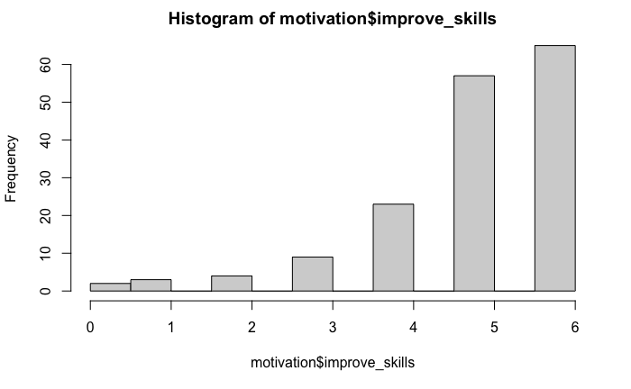

```r
hist(motivation$improve_skills)
```

```r
lowerCor(motivation)
```

```
                      mntr_ excl_ intrn intr_ gt_n_ knwn_ impr_ tst_c enjy_ kep_p dssts curis pss_c
monetary_compensation  1.00
excellent_programmer   0.44  1.00
internship             0.32  0.51  1.00
introduce_ideas        0.36  0.50  0.43  1.00
get_in_touch           0.34  0.57  0.54  0.62  1.00
known_creativity       0.34  0.66  0.49  0.50  0.47  1.00
improve_skills         0.30  0.44  0.46  0.23  0.47  0.33  1.00
test_capability        0.33  0.53  0.46  0.42  0.62  0.43  0.67  1.00
enjoy_problems         0.32  0.52  0.49  0.48  0.59  0.52  0.53  0.66  1.00
keep_up                0.32  0.49  0.48  0.41  0.49  0.48  0.60  0.63  0.57  1.00
dissatisfaction        0.23  0.38  0.30  0.56  0.39  0.33  0.29  0.33  0.40  0.38  1.00
curious                0.27  0.37  0.48  0.45  0.47  0.50  0.41  0.42  0.52  0.48  0.33  1.00
pass_class             0.03 -0.01 -0.15 -0.20 -0.20 -0.05 -0.09 -0.07 -0.24 -0.19 -0.13 -0.25  1.00
```

### Interpretation:

> Pearson correlations indicate the items have non-trivial pairwise interrelationships. Particularly, none of the item pairs have near-zero or very small correlations, except for the “pass_class” item.

```r
library(correlation)

correlation::correlation(motivation,
                         include_factors = TRUE, method = "auto"
)
```

```
# Correlation Matrix (auto-method)

Parameter1            |           Parameter2 |     r |         95% CI | t(161) |         p
------------------------------------------------------------------------------------------
monetary_compensation | excellent_programmer |  0.44 | [ 0.31,  0.56] |   6.22 | < .001***
monetary_compensation |           internship |  0.32 | [ 0.18,  0.46] |   4.36 | < .001***
monetary_compensation |      introduce_ideas |  0.36 | [ 0.22,  0.49] |   4.96 | < .001***
monetary_compensation |         get_in_touch |  0.34 | [ 0.20,  0.47] |   4.62 | < .001***
monetary_compensation |     known_creativity |  0.34 | [ 0.19,  0.47] |   4.56 | < .001***
monetary_compensation |       improve_skills |  0.30 | [ 0.15,  0.43] |   4.01 | 0.002**
monetary_compensation |      test_capability |  0.33 | [ 0.18,  0.46] |   4.38 | < .001***
monetary_compensation |       enjoy_problems |  0.32 | [ 0.18,  0.45] |   4.32 | < .001***
monetary_compensation |              keep_up |  0.32 | [ 0.18,  0.45] |   4.33 | < .001***
monetary_compensation |      dissatisfaction |  0.23 | [ 0.08,  0.37] |   2.96 | 0.042*
monetary_compensation |              curious |  0.27 | [ 0.12,  0.40] |   3.51 | 0.009**
monetary_compensation |           pass_class |  0.03 | [-0.13,  0.18] |   0.37 | > .999
excellent_programmer  |           internship |  0.51 | [ 0.39,  0.62] |   7.61 | < .001***
excellent_programmer  |      introduce_ideas |  0.50 | [ 0.37,  0.61] |   7.31 | < .001***
excellent_programmer  |         get_in_touch |  0.57 | [ 0.46,  0.67] |   8.81 | < .001***
excellent_programmer  |     known_creativity |  0.66 | [ 0.56,  0.74] |  11.05 | < .001***
excellent_programmer  |       improve_skills |  0.44 | [ 0.31,  0.56] |   6.22 | < .001***
excellent_programmer  |      test_capability |  0.53 | [ 0.41,  0.63] |   7.95 | < .001***
excellent_programmer  |       enjoy_problems |  0.52 | [ 0.40,  0.62] |   7.68 | < .001***
excellent_programmer  |              keep_up |  0.49 | [ 0.36,  0.60] |   7.10 | < .001***
excellent_programmer  |      dissatisfaction |  0.38 | [ 0.24,  0.51] |   5.24 | < .001***
excellent_programmer  |              curious |  0.37 | [ 0.23,  0.50] |   5.11 | < .001***
excellent_programmer  |           pass_class | -0.01 | [-0.17,  0.14] |  -0.17 | > .999
internship            |      introduce_ideas |  0.43 | [ 0.29,  0.54] |   5.97 | < .001***
internship            |         get_in_touch |  0.54 | [ 0.42,  0.64] |   8.14 | < .001***
internship            |     known_creativity |  0.49 | [ 0.37,  0.60] |   7.18 | < .001***
internship            |       improve_skills |  0.46 | [ 0.33,  0.57] |   6.60 | < .001***
internship            |      test_capability |  0.46 | [ 0.33,  0.57] |   6.52 | < .001***
internship            |       enjoy_problems |  0.49 | [ 0.36,  0.60] |   7.11 | < .001***
internship            |              keep_up |  0.48 | [ 0.35,  0.59] |   6.95 | < .001***
internship            |      dissatisfaction |  0.30 | [ 0.16,  0.44] |   4.02 | 0.002**
internship            |              curious |  0.48 | [ 0.35,  0.59] |   6.93 | < .001***
internship            |           pass_class | -0.15 | [-0.30,  0.00] |  -1.96 | 0.364
introduce_ideas       |         get_in_touch |  0.62 | [ 0.52,  0.71] |  10.15 | < .001***
introduce_ideas       |     known_creativity |  0.50 | [ 0.38,  0.61] |   7.37 | < .001***
introduce_ideas       |       improve_skills |  0.23 | [ 0.08,  0.37] |   2.96 | 0.042*
```

[output cut: 30 more lines]

```
test_capability       |              curious |  0.42 | [ 0.29,  0.54] |   5.91 | < .001***
test_capability       |           pass_class | -0.07 | [-0.23,  0.08] |  -0.94 | > .999
enjoy_problems        |              keep_up |  0.57 | [ 0.46,  0.67] |   8.91 | < .001***
enjoy_problems        |      dissatisfaction |  0.40 | [ 0.26,  0.52] |   5.55 | < .001***
enjoy_problems        |              curious |  0.52 | [ 0.40,  0.62] |   7.69 | < .001***
enjoy_problems        |           pass_class | -0.24 | [-0.38, -0.09] |  -3.09 | 0.030*
keep_up               |      dissatisfaction |  0.38 | [ 0.24,  0.50] |   5.17 | < .001***
keep_up               |              curious |  0.48 | [ 0.35,  0.59] |   6.89 | < .001***
keep_up               |           pass_class | -0.19 | [-0.34, -0.04] |  -2.51 | 0.104
dissatisfaction       |              curious |  0.33 | [ 0.19,  0.46] |   4.44 | < .001***
dissatisfaction       |           pass_class | -0.13 | [-0.28,  0.02] |  -1.67 | 0.587
curious               |           pass_class | -0.25 | [-0.39, -0.10] |  -3.26 | 0.019*

p-value adjustment method: Holm (1979)
Observations: 163
```

### Interpretation:

```
Parallel analysis suggests that the number of factors =  3  and the number of components =  NA
```

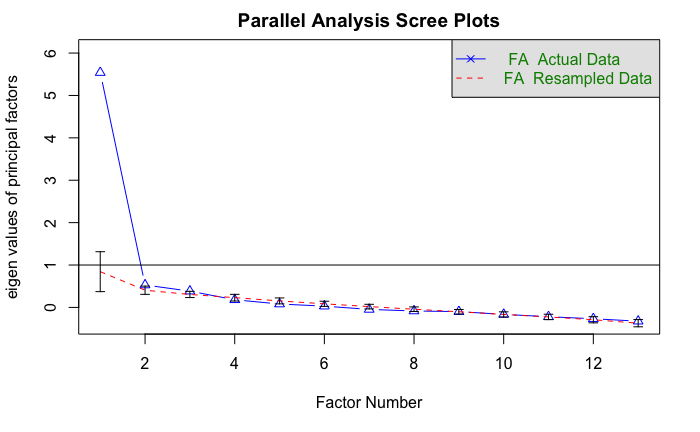

```r
all_motivation <- fa.parallel(motivation, fm='ml', fa='fa', main="Parallel Analysis Scree Plots", n.iter=100, error.bars=T, sim=F)
```

```r
all_motivation
```

```
Call: fa.parallel(x = motivation, fm = "ml", fa = "fa", main = "Parallel Analysis Scree Plots",
    n.iter = 100, error.bars = T, sim = F)
Parallel analysis suggests that the number of factors =  3  and the number of components =  NA

 Eigen Values of

 eigen values of factors
 [1]  5.54  0.53  0.38  0.18  0.08  0.03 -0.05 -0.08 -0.10 -0.16 -0.22 -0.27 -0.33

 eigen values of simulated factors
[1] NA

 eigen values of components
 [1] 6.06 1.16 1.08 0.78 0.71 0.60 0.55 0.52 0.40 0.38 0.28 0.25 0.24

 eigen values of simulated components
[1] NA
```

## Interpretation:

> Parallel analysis suggests that the number of factors = 3

```r
all_motivation <- fa(r=motivation, nfactors=2, rotate='promax', fm='ml')
all_motivation
```

```
Factor Analysis using method =  ml
Call: fa(r = motivation, nfactors = 2, rotate = "promax", fm = "ml")
Standardized loadings (pattern matrix) based upon correlation matrix
```

|  | ML1 | ML2 | h2 | u2 | com |
| --- | --- | --- | --- | --- | --- |
| monetary_compensation | 0.18 | 0.32 | 0.22029219 | 0.7797078 | 1.569628 |
| excellent_programmer | 0.31 | 0.46 | 0.51545299 | 0.4845470 | 1.759177 |
| internship | 0.38 | 0.32 | 0.43407922 | 0.5659208 | 1.940129 |
| introduce_ideas | -0.30 | 1.06 | 0.74371947 | 0.2562805 | 1.159186 |
| get_in_touch | 0.28 | 0.55 | 0.61606919 | 0.3839308 | 1.495697 |
| known_creativity | 0.17 | 0.55 | 0.46058662 | 0.5394134 | 1.183956 |
| improve_skills | 1.04 | -0.33 | 0.68573755 | 0.3142625 | 1.196703 |
| test_capability | 0.82 | 0.01 | 0.68785886 | 0.3121411 | 1.000495 |
| enjoy_problems | 0.54 | 0.28 | 0.59685443 | 0.4031456 | 1.511339 |
| keep_up | 0.68 | 0.10 | 0.57041535 | 0.4295847 | 1.040821 |

[output cut: 3 more lines]

```
                       ML1  ML2
SS loadings           3.24 3.09
Proportion Var        0.25 0.24
Cumulative Var        0.25 0.49
Proportion Explained  0.51 0.49
Cumulative Proportion 0.51 1.00

 With factor correlations of
     ML1  ML2
ML1 1.00 0.74
ML2 0.74 1.00

Mean item complexity =  1.4
Test of the hypothesis that 2 factors are sufficient.

The degrees of freedom for the null model are  78  and the objective function was  6.31 with Chi Square of  989.47
The degrees of freedom for the model are 53  and the objective function was  0.64

The root mean square of the residuals (RMSR) is  0.05
The df corrected root mean square of the residuals is  0.06

The harmonic number of observations is  163 with the empirical chi square  62.87  with prob <  0.17
The total number of observations was  163  with Likelihood Chi Square =  100.25  with prob <  9.5e-05

Tucker Lewis Index of factoring reliability =  0.923
RMSEA index =  0.074  and the 90 % confidence intervals are  0.052 0.096
BIC =  -169.71
Fit based upon off diagonal values = 0.99
Measures of factor score adequacy
                                                   ML1  ML2
Correlation of (regression) scores with factors   0.95 0.95
Multiple R square of scores with factors          0.90 0.90
Minimum correlation of possible factor scores     0.81 0.79
```

## Interpretation:

> ML1 - “improve_skills”, “test_capability”, “enjoy_problems”, “keep_up” [ intrinsic ]

> ML2 = “excellent_programmer”, “introduce_ideas”, “get_in_touch”, “known_creativity”, “dissatisfaction” [ extrinsic ]

```r
all_motivation <- fa(r=motivation, nfactors=3, rotate='promax', fm='ml')
all_motivation
```

```
Factor Analysis using method =  ml
Call: fa(r = motivation, nfactors = 3, rotate = "promax", fm = "ml")
Standardized loadings (pattern matrix) based upon correlation matrix
```

|  | ML3 | ML1 | ML2 | h2 | u2 | com |
| --- | --- | --- | --- | --- | --- | --- |
| monetary_compensation | 0.08 | 0.43 | 0.01 | 0.2440129 | 0.7559871 | 1.079497 |
| excellent_programmer | 0.08 | 1.08 | -0.35 | 0.8926294 | 0.1073706 | 1.217746 |
| internship | 0.33 | 0.33 | 0.08 | 0.4300250 | 0.5699750 | 2.106291 |
| introduce_ideas | -0.37 | 0.44 | 0.81 | 0.8376122 | 0.1623878 | 2.003193 |
| get_in_touch | 0.24 | 0.33 | 0.33 | 0.6136410 | 0.3863590 | 2.798278 |
| known_creativity | 0.06 | 0.68 | 0.01 | 0.5245523 | 0.4754477 | 1.014964 |
| improve_skills | 0.94 | -0.03 | -0.18 | 0.6654708 | 0.3345292 | 1.077637 |
| test_capability | 0.74 | 0.10 | 0.02 | 0.6878633 | 0.3121367 | 1.040981 |
| enjoy_problems | 0.52 | 0.16 | 0.19 | 0.6038311 | 0.3961689 | 1.484401 |
| keep_up | 0.63 | 0.11 | 0.08 | 0.5758244 | 0.4241756 | 1.091867 |

[output cut: 3 more lines]

```
                       ML3  ML1  ML2
SS loadings           2.69 2.79 1.48
Proportion Var        0.21 0.21 0.11
Cumulative Var        0.21 0.42 0.54
Proportion Explained  0.39 0.40 0.21
Cumulative Proportion 0.39 0.79 1.00

 With factor correlations of
     ML3  ML1  ML2
ML3 1.00 0.66 0.63
ML1 0.66 1.00 0.64
ML2 0.63 0.64 1.00

Mean item complexity =  1.6
Test of the hypothesis that 3 factors are sufficient.

The degrees of freedom for the null model are  78  and the objective function was  6.31 with Chi Square of  989.47
The degrees of freedom for the model are 42  and the objective function was  0.38

The root mean square of the residuals (RMSR) is  0.04
The df corrected root mean square of the residuals is  0.05

The harmonic number of observations is  163 with the empirical chi square  31.87  with prob <  0.87
The total number of observations was  163  with Likelihood Chi Square =  59.46  with prob <  0.039

Tucker Lewis Index of factoring reliability =  0.964
RMSEA index =  0.05  and the 90 % confidence intervals are  0.012 0.079
BIC =  -154.47
Fit based upon off diagonal values = 0.99
Measures of factor score adequacy
                                                   ML3  ML1  ML2
Correlation of (regression) scores with factors   0.94 0.97 0.93
Multiple R square of scores with factors          0.89 0.94 0.87
Minimum correlation of possible factor scores     0.77 0.87 0.73
```

## Interpretation:

> ML3 - “improve_skills”, “test_capability”, “enjoy_problems”, “keep_up” [ intrinsic motivation ]

> ML1 - “known_creativity”, “excellent_programmer” [ recognition ]

> ML2 - “introduce_ideas”, “dissatisfaction” [ misc extrinc motivation ]

```r
motivation_9_items <- motivation[ , -c(1,3, 12, 13)]
motivation_9_items
```

| excellent_programmer | introduce_ideas | get_in_touch | known_creativity | improve_skills | test_capability | enjoy_problems | keep_up | dissatisfaction |
| --- | --- | --- | --- | --- | --- | --- | --- | --- |
| 5 | 3 | 4 | 3 | 5 | 5 | 3 | 3 | 3 |
| 5 | 2 | 3 | 3 | 5 | 4 | 3 | 4 | 3 |
| 2 | 2 | 2 | 2 | 6 | 5 | 3 | 6 | 4 |
| 4 | 0 | 0 | 0 | 6 | 6 | 5 | 6 | 0 |
| 5 | 2 | 2 | 3 | 5 | 4 | 3 | 4 | 4 |
| 4 | 2 | 4 | 2 | 5 | 4 | 5 | 5 | 3 |
| 2 | 2 | 2 | 4 | 5 | 5 | 4 | 5 | 1 |
| 5 | 3 | 4 | 5 | 5 | 4 | 4 | 5 | 3 |
| 3 | 3 | 4 | 5 | 6 | 4 | 5 | 5 | 4 |
| 6 | 4 | 5 | 5 | 6 | 6 | 5 | 5 | 5 |

[output cut: 153 more lines]

```r
correl = cor(motivation_9_items, use = 'pairwise.complete.obs')
symnum(correl)
```

```
                     ex_ in_ g kn_ im_ t en_ kp_ d
excellent_programmer 1
introduce_ideas      .   1
get_in_touch         .   ,   1
known_creativity     ,   .   . 1
improve_skills       .       . .   1
test_capability      .   .   , .   ,   1
enjoy_problems       .   .   . .   .   , 1
keep_up              .   .   . .   .   , .   1
dissatisfaction      .   .   . .       . .   .   1
attr(,"legend")
[1] 0 ‘ ’ 0.3 ‘.’ 0.6 ‘,’ 0.8 ‘+’ 0.9 ‘*’ 0.95 ‘B’ 1
```

```r
correl
```

```
                     excellent_programmer introduce_ideas get_in_touch known_creativity improve_skills test_capability enjoy_problems
excellent_programmer            1.0000000       0.4991295    0.5702696        0.6566655      0.4401608       0.5310235      0.5175774
introduce_ideas                 0.4991295       1.0000000    0.6245920        0.5021195      0.2268728       0.4243225      0.4835113
get_in_touch                    0.5702696       0.6245920    1.0000000        0.4735861      0.4678210       0.6241206      0.5888826
known_creativity                0.6566655       0.5021195    0.4735861        1.0000000      0.3298796       0.4296513      0.5151683
improve_skills                  0.4401608       0.2268728    0.4678210        0.3298796      1.0000000       0.6687359      0.5262480
test_capability                 0.5310235       0.4243225    0.6241206        0.4296513      0.6687359       1.0000000      0.6581295
enjoy_problems                  0.5175774       0.4835113    0.5888826        0.5151683      0.5262480       0.6581295      1.0000000
keep_up                         0.4884620       0.4147623    0.4884778        0.4780050      0.5992564       0.6250949      0.5745277
dissatisfaction                 0.3814222       0.5619457    0.3946728        0.3319538      0.2877562       0.3336964      0.4007982
                       keep_up dissatisfaction
excellent_programmer 0.4884620       0.3814222
introduce_ideas      0.4147623       0.5619457
get_in_touch         0.4884778       0.3946728
known_creativity     0.4780050       0.3319538
improve_skills       0.5992564       0.2877562
test_capability      0.6250949       0.3336964
enjoy_problems       0.5745277       0.4007982
keep_up              1.0000000       0.3773620
dissatisfaction      0.3773620       1.0000000
```

```r
# Conducting Bartlett test
cortest.bartlett(correl, n=nrow(motivation_9_items))
```

```
$chisq
[1] 751.8133

$p.value
[1] 9.798317e-135

$df
[1] 36
```

## Interpretation:

> p-value is significant which means that the correlation is large enough for us to continue.

```r
KMO(motivation_9_items)
```

```
Kaiser-Meyer-Olkin factor adequacy
Call: KMO(r = motivation_9_items)
Overall MSA =  0.88
MSA for each item =
excellent_programmer      introduce_ideas         get_in_touch     known_creativity       improve_skills      test_capability
                0.89                 0.81                 0.89                 0.86                 0.85                 0.88
      enjoy_problems              keep_up      dissatisfaction
                0.93                 0.92                 0.86
```

```
Parallel analysis suggests that the number of factors =  2  and the number of components =  NA
```

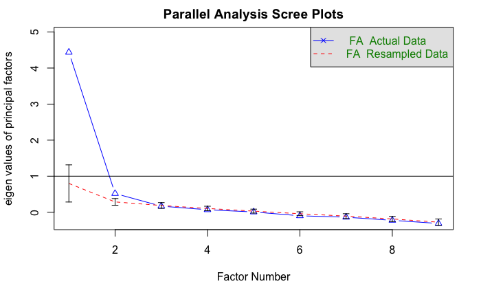

```r
fa.parallel(motivation_9_items, fm='ml', fa='fa', main="Parallel Analysis Scree Plots", n.iter=100, error.bars=T, sim=F)
```

## Interpretation:

> Parallel analysis suggests that the number of factors = 2

```r
# remove survey item 1, 3, 12, 13
# remove "monetary_compensation", "internship", "curious" and "pass_class"

fa(r=motivation_9_items, nfactors=2, rotate='promax', fm='ml')
```

```
Factor Analysis using method =  ml
Call: fa(r = motivation_9_items, nfactors = 2, rotate = "promax", fm = "ml")
Standardized loadings (pattern matrix) based upon correlation matrix
```

|  | ML2 | ML1 | h2 | u2 | com |
| --- | --- | --- | --- | --- | --- |
| excellent_programmer | 0.35 | 0.42 | 0.5013257 | 0.4986743 | 1.936011 |
| introduce_ideas | -0.27 | 1.06 | 0.7991926 | 0.2008074 | 1.132228 |
| get_in_touch | 0.32 | 0.53 | 0.6137280 | 0.3862720 | 1.646127 |
| known_creativity | 0.21 | 0.49 | 0.4268795 | 0.5731205 | 1.363206 |
| improve_skills | 0.97 | -0.27 | 0.6501871 | 0.3498129 | 1.149137 |
| test_capability | 0.83 | 0.03 | 0.7266630 | 0.2733370 | 1.001963 |
| enjoy_problems | 0.57 | 0.26 | 0.5948080 | 0.4051920 | 1.396711 |
| keep_up | 0.67 | 0.10 | 0.5615782 | 0.4384218 | 1.047360 |
| dissatisfaction | -0.02 | 0.62 | 0.3679098 | 0.6320902 | 1.002723 |

```
                       ML2  ML1
SS loadings           2.82 2.42
Proportion Var        0.31 0.27
Cumulative Var        0.31 0.58
Proportion Explained  0.54 0.46
Cumulative Proportion 0.54 1.00

 With factor correlations of
    ML2 ML1
ML2 1.0 0.7
ML1 0.7 1.0

Mean item complexity =  1.3
Test of the hypothesis that 2 factors are sufficient.

The degrees of freedom for the null model are  36  and the objective function was  4.75 with Chi Square of  751.81
The degrees of freedom for the model are 19  and the objective function was  0.3

The root mean square of the residuals (RMSR) is  0.04
The df corrected root mean square of the residuals is  0.06

The harmonic number of observations is  163 with the empirical chi square  21.95  with prob <  0.29
The total number of observations was  163  with Likelihood Chi Square =  47.57  with prob <  3e-04

Tucker Lewis Index of factoring reliability =  0.924
RMSEA index =  0.096  and the 90 % confidence intervals are  0.062 0.131
BIC =  -49.21
Fit based upon off diagonal values = 0.99
Measures of factor score adequacy
                                                   ML2  ML1
Correlation of (regression) scores with factors   0.95 0.95
Multiple R square of scores with factors          0.90 0.90
Minimum correlation of possible factor scores     0.79 0.79
```

### Interpretation:

> Items loaded on ML1 - “excellent_programmer”, “introduce_ideas”, “get_in_touch”, “known_creativity” and “dissatisfaction”.
- “excellent_programmer”, “introduce_ideas”, “get_in_touch” and “known_creativity” are under “SHOW IDEAS” category in Fuller paper. “dissatisfaction” is under the category of “DISSATISFACTION” in Fuller paper. Both “SHOW IDEAS” and “DISSATISFACTION” lie on the “EXTRINSIC” side of motivations in Fuller paper.

> Items loaded on ML2 - “improve_skills”, “test_capability”, “enjoy_problems”, “keep_up”
- “improve_skills” and “test_capability”are under the category of “GAIN KNOWLEDGE” in Fuller paper. “enjoy_problems” and “keep_up” are under the category of “INTRINSIC INNOVATION INTEREST” in Fuller paper. Both “GAIN KNOWLEDGE” and “INTRINSIC INNOVATION INTEREST” lie on the “INTRINSIC” side of motivations in Fuller paper.

> Tucker Lewis Index is a model fit statistic. Rule-of-thumb is that models with TLI > .90 fit the data well (Little, 2013, Longitudinal structural equation modeling)
- Comment: 0.924 ( Great )

> Root mean square error of approximation (RMSEA) is another model fit statistic. Rule-of-thumb is that models with RMSEA ≤ .05 fit the data well, ≤ .08 fit the data acceptably, and .08 - .10 is marginally acceptable fit (Little, 2013).
- Comment: 0.096 ( marginally acceptable fit )

```r
## get cfi of the 9 loaded survey items

finalmodel = fa(r=motivation[ , -c(1,3,12,13)], nfactors=2, rotate='promax', fm='ml')
1 - ((finalmodel$STATISTIC-finalmodel$dof)/
       (finalmodel$null.chisq-finalmodel$null.dof))
```

```
[1] 0.9600847
```

# Interpretation:

> Very high CFI value of 0.96, larger than threhold of 0.95

```r
## reliability for the 9 survey items.

factor1 = c(7, 8, 9, 10)
factor2 = c(2, 4, 5, 6, 11)

psych::alpha(motivation[ , factor1])
```

```
Reliability analysis
Call: psych::alpha(x = motivation[, factor1])
```

|  | raw_alpha | std.alpha | G6(smc) | average_r | S/N | ase | mean | sd | median_r |
| --- | --- | --- | --- | --- | --- | --- | --- | --- | --- |
|  | 0.8603579 | 0.8615233 | 0.8290301 | 0.6086654 | 6.221432 | 0.01781145 | 4.46319 | 1.129444 | 0.6121756 |

```
 lower alpha upper     95% confidence boundaries
0.83 0.86 0.9

 Reliability if an item is dropped:
```

|  | raw_alpha | std.alpha | G6(smc) | average_r | S/N | alpha se | var.r | med.r |
| --- | --- | --- | --- | --- | --- | --- | --- | --- |
| improve_skills | 0.8290581 | 0.8299088 | 0.7675076 | 0.6192507 | 4.879200 | 0.02305415 | 0.001772932 | 0.6250949 |
| test_capability | 0.7938618 | 0.7968820 | 0.7253585 | 0.5666774 | 3.923248 | 0.02789968 | 0.001378775 | 0.5745277 |
| enjoy_problems | 0.8364848 | 0.8368871 | 0.7755765 | 0.6310291 | 5.130722 | 0.02208497 | 0.001233263 | 0.6250949 |
| keep_up | 0.8273594 | 0.8289818 | 0.7739018 | 0.6177045 | 4.847332 | 0.02340717 | 0.006301336 | 0.6581295 |

```
 Item statistics
```

|  | n | raw.r | std.r | r.cor | r.drop | mean | sd |
| --- | --- | --- | --- | --- | --- | --- | --- |
| improve_skills | 163 | 0.8222359 | 0.8310898 | 0.7506903 | 0.6904460 | 4.938650 | 1.260478 |
| test_capability | 163 | 0.8803559 | 0.8780004 | 0.8339061 | 0.7719208 | 4.380368 | 1.375305 |
| enjoy_problems | 163 | 0.8318798 | 0.8205801 | 0.7312517 | 0.6772542 | 4.085890 | 1.450410 |
| keep_up | 163 | 0.8267979 | 0.8324695 | 0.7454170 | 0.6938214 | 4.447853 | 1.286940 |

```
Non missing response frequency for each item
                   0    1    2    3    4    5    6 miss
improve_skills  0.01 0.02 0.02 0.06 0.14 0.35 0.40    0
test_capability 0.03 0.02 0.04 0.10 0.26 0.36 0.19    0
enjoy_problems  0.04 0.04 0.04 0.16 0.26 0.33 0.13    0
keep_up         0.02 0.01 0.04 0.14 0.21 0.39 0.19    0
```

```r
psych::alpha(motivation[ , factor2])
```

```
Reliability analysis
Call: psych::alpha(x = motivation[, factor2])
```

|  | raw_alpha | std.alpha | G6(smc) | average_r | S/N | ase | mean | sd | median_r |
| --- | --- | --- | --- | --- | --- | --- | --- | --- | --- |
|  | 0.8323389 | 0.8331308 | 0.8231133 | 0.4996357 | 4.992719 | 0.02094349 | 3.548466 | 1.192899 | 0.5006245 |

```
 lower alpha upper     95% confidence boundaries
0.79 0.83 0.87

 Reliability if an item is dropped:
```

|  | raw_alpha | std.alpha | G6(smc) | average_r | S/N | alpha se | var.r | med.r |
| --- | --- | --- | --- | --- | --- | --- | --- | --- |
| excellent_programmer | 0.7885292 | 0.7878767 | 0.7526999 | 0.4814783 | 3.714239 | 0.02697652 | 0.011467528 | 0.4878528 |
| introduce_ideas | 0.7758410 | 0.7787679 | 0.7449998 | 0.4680950 | 3.520140 | 0.02902301 | 0.015493208 | 0.4341295 |
| get_in_touch | 0.7912933 | 0.7927821 | 0.7693026 | 0.4888727 | 3.825839 | 0.02709439 | 0.013988782 | 0.5006245 |
| known_creativity | 0.8033448 | 0.8033950 | 0.7711128 | 0.5053386 | 4.086340 | 0.02528831 | 0.009856498 | 0.5305376 |
| dissatisfaction | 0.8320217 | 0.8326789 | 0.8048830 | 0.5543937 | 4.976534 | 0.02166482 | 0.005591188 | 0.5361945 |

```
 Item statistics
```

|  | n | raw.r | std.r | r.cor | r.drop | mean | sd |
| --- | --- | --- | --- | --- | --- | --- | --- |
| excellent_programmer | 163 | 0.7957515 | 0.8025446 | 0.7498872 | 0.6686843 | 4.061350 | 1.497707 |
| introduce_ideas | 163 | 0.8290658 | 0.8232830 | 0.7762375 | 0.7087135 | 2.987730 | 1.594697 |
| get_in_touch | 163 | 0.7932715 | 0.7910865 | 0.7239348 | 0.6572099 | 3.748466 | 1.564828 |
| known_creativity | 163 | 0.7549971 | 0.7655714 | 0.6936773 | 0.6157324 | 3.846626 | 1.446933 |
| dissatisfaction | 163 | 0.6982557 | 0.6895571 | 0.5691966 | 0.5150121 | 3.098160 | 1.599439 |

```
Non missing response frequency for each item
                        0    1    2    3    4    5    6 miss
excellent_programmer 0.04 0.03 0.06 0.20 0.23 0.28 0.17    0
introduce_ideas      0.10 0.09 0.11 0.31 0.23 0.11 0.05    0
get_in_touch         0.06 0.04 0.10 0.17 0.29 0.23 0.12    0
known_creativity     0.05 0.03 0.04 0.23 0.28 0.27 0.09    0
dissatisfaction      0.09 0.09 0.12 0.30 0.18 0.17 0.05    0
```

# Interpretation:

> raw_alpha for factor 1 is 0.86 which is good

```r
## create average factor scores for each person

motivation$f1 = apply(motivation[ , factor1], 1, sum)
motivation$f2 = apply(motivation[ , factor2], 1, sum)
summary(motivation)
```

```
 monetary_compensation excellent_programmer   internship    introduce_ideas  get_in_touch   known_creativity improve_skills
 Min.   :0.000         Min.   :0.000        Min.   :0.000   Min.   :0.000   Min.   :0.000   Min.   :0.000    Min.   :0.000
 1st Qu.:2.000         1st Qu.:3.000        1st Qu.:3.000   1st Qu.:2.000   1st Qu.:3.000   1st Qu.:3.000    1st Qu.:4.500
 Median :3.000         Median :4.000        Median :4.000   Median :3.000   Median :4.000   Median :4.000    Median :5.000
 Mean   :2.896         Mean   :4.061        Mean   :4.153   Mean   :2.988   Mean   :3.748   Mean   :3.847    Mean   :4.939
 3rd Qu.:4.000         3rd Qu.:5.000        3rd Qu.:5.000   3rd Qu.:4.000   3rd Qu.:5.000   3rd Qu.:5.000    3rd Qu.:6.000
 Max.   :6.000         Max.   :6.000        Max.   :6.000   Max.   :6.000   Max.   :6.000   Max.   :6.000    Max.   :6.000
 test_capability enjoy_problems     keep_up      dissatisfaction    curious        pass_class          f1              f2
 Min.   :0.00    Min.   :0.000   Min.   :0.000   Min.   :0.000   Min.   :0.000   Min.   :0.000   Min.   : 0.00   Min.   : 0.00
 1st Qu.:4.00    1st Qu.:3.000   1st Qu.:4.000   1st Qu.:2.000   1st Qu.:3.000   1st Qu.:3.500   1st Qu.:16.00   1st Qu.:15.00
 Median :5.00    Median :4.000   Median :5.000   Median :3.000   Median :4.000   Median :5.000   Median :19.00   Median :18.00
 Mean   :4.38    Mean   :4.086   Mean   :4.448   Mean   :3.098   Mean   :3.847   Mean   :4.331   Mean   :17.85   Mean   :17.74
 3rd Qu.:5.00    3rd Qu.:5.000   3rd Qu.:5.000   3rd Qu.:4.000   3rd Qu.:5.000   3rd Qu.:6.000   3rd Qu.:21.00   3rd Qu.:22.50
 Max.   :6.00    Max.   :6.000   Max.   :6.000   Max.   :6.000   Max.   :6.000   Max.   :6.000   Max.   :24.00   Max.   :30.00
```

```r
View(motivation)
```

## Validation

> Subsample for Bogota 0

```r
# subset of bogota 0
survey_bogota_0 <- subset(survey, hack_id == 0)
survey_bogota_0
```

|  | monetary_compensation | excellent_programmer | internship | introduce_ideas | get_in_touch | known_creativity | improve_skills | test_capability | enjoy_problems | keep_up | dissatisfaction | curious | pass_class | Q3_Q3_1 | Q3_Q3_2 | Q3_Q3_3 | Q3_Q3_4 | Q3_Q3_5 | Q4_Q4_1 | Q4_Q4_2 | Q4_Q4_3 | Q4_Q4_4 | Q4_Q4_5 | Q5_Q5_1 | Q5_Q5_2 | Q5_Q5_3 | Q5_Q5_4 | Q5_Q5_5 | Q7_Q7_1 | … |
| --- | --- | --- | --- | --- | --- | --- | --- | --- | --- | --- | --- | --- | --- | --- | --- | --- | --- | --- | --- | --- | --- | --- | --- | --- | --- | --- | --- | --- | --- | --- |
| 2 | 2 | 5 | 2 | 2 | 3 | 3 | 5 | 4 | 3 | 4 | 3 | 4 | 5 | 1 | 5 | 3 | 4 | 3 | 3 | 6 | 5 | 3 | 4 | 1 | 1 | 3 | 3 | 4 | 0 | … |
| 6 | 3 | 4 | 4 | 2 | 4 | 2 | 5 | 4 | 5 | 5 | 3 | 4 | 5 | 3 | 4 | 5 | 3 | 5 | 3 | 3 | 2 | 4 | 3 | 3 | 2 | 4 | 2 | 5 | 1 | … |
| 10 | 3 | 6 | 6 | 4 | 5 | 5 | 6 | 6 | 5 | 5 | 5 | 5 | 6 | 4 | 5 | 5 | 4 | 6 | 5 | 4 | 5 | 5 | 6 | 5 | 2 | 5 | 2 | 5 | 1 | … |
| 14 | 0 | 3 | 4 | 3 | 0 | 5 | 5 | 3 | 3 | 4 | 4 | 5 | 5 | 5 | 3 | 4 | 4 | 4 | 4 | 3 | 4 | 5 | 3 | 3 | 3 | 4 | 3 | 4 | 3 | … |
| 18 | 4 | 3 | 6 | 4 | 6 | 3 | 6 | 6 | 6 | 6 | 3 | 5 | 2 | 5 | 6 | 6 | 6 | 6 | 6 | 4 | 6 | 4 | 5 | 2 | 2 | 5 | 3 | 6 | 1 | … |
| 22 | 3 | 5 | 6 | 5 | 6 | 5 | 5 | 6 | 5 | 5 | 4 | 5 | 4 | 3 | 5 | 2 | 5 | 4 | 3 | 4 | 4 | 4 | 5 | 2 | 3 | 2 | 3 | 4 | 0 | … |
| 26 | 3 | 5 | 4 | 4 | 2 | 5 | 4 | 0 | 2 | 5 | 4 | 5 | 4 | 4 | 4 | 3 | 5 | 4 | 3 | 3 | 3 | 3 | 3 | 3 | 3 | 3 | 3 | 4 | 2 | … |
| 30 | 3 | 3 | 4 | 3 | 4 | 5 | 5 | 4 | 4 | 3 | 3 | 3 | 5 | 4 | 5 | 5 | 5 | 5 | 4 | 5 | 4 | 5 | 4 | 4 | 3 | 4 | 4 | 5 | 3 | … |
| 36 | 3 | 5 | 5 | 3 | 5 | 5 | 6 | 5 | 5 | 5 | 4 | 6 | 3 | 5 | 5 | 5 | 5 | 5 | 5 | 5 | 5 | 5 | 5 | 4 | 3 | 4 | 3 | 4 | 3 | … |
| 39 | 3 | 5 | 6 | 6 | 6 | 4 | 5 | 5 | 5 | 6 | 5 | 0 | 4 | 5 | 5 | 4 | 6 | 5 | 5 | 3 | 5 | 5 | 6 | 5 | 1 | 6 | 5 | 6 | 3 | … |

[output cut: 30 more lines]

```r
# bogota 0 all 13 motivation constructs

motivation_bogota_0 <- survey_bogota_0[c(1:13)]
motivation_bogota_0
```

|  | monetary_compensation | excellent_programmer | internship | introduce_ideas | get_in_touch | known_creativity | improve_skills | test_capability | enjoy_problems | keep_up | dissatisfaction | curious | pass_class |
| --- | --- | --- | --- | --- | --- | --- | --- | --- | --- | --- | --- | --- | --- |
| 2 | 2 | 5 | 2 | 2 | 3 | 3 | 5 | 4 | 3 | 4 | 3 | 4 | 5 |
| 6 | 3 | 4 | 4 | 2 | 4 | 2 | 5 | 4 | 5 | 5 | 3 | 4 | 5 |
| 10 | 3 | 6 | 6 | 4 | 5 | 5 | 6 | 6 | 5 | 5 | 5 | 5 | 6 |
| 14 | 0 | 3 | 4 | 3 | 0 | 5 | 5 | 3 | 3 | 4 | 4 | 5 | 5 |
| 18 | 4 | 3 | 6 | 4 | 6 | 3 | 6 | 6 | 6 | 6 | 3 | 5 | 2 |
| 22 | 3 | 5 | 6 | 5 | 6 | 5 | 5 | 6 | 5 | 5 | 4 | 5 | 4 |
| 26 | 3 | 5 | 4 | 4 | 2 | 5 | 4 | 0 | 2 | 5 | 4 | 5 | 4 |
| 30 | 3 | 3 | 4 | 3 | 4 | 5 | 5 | 4 | 4 | 3 | 3 | 3 | 5 |
| 36 | 3 | 5 | 5 | 3 | 5 | 5 | 6 | 5 | 5 | 5 | 4 | 6 | 3 |
| 39 | 3 | 5 | 6 | 6 | 6 | 4 | 5 | 5 | 5 | 6 | 5 | 0 | 4 |

[output cut: 30 more lines]

```r
describe(motivation_bogota_0)
```

|  | vars | n | mean | sd | median | trimmed | mad | min | max | range | skew | kurtosis | se |
| --- | --- | --- | --- | --- | --- | --- | --- | --- | --- | --- | --- | --- | --- |
| monetary_compensation | 1 | 40 | 2.70 | 1.64 | 3 | 2.72 | 1.48 | 0 | 6 | 6 | -0.28 | -0.93 | 0.26 |
| excellent_programmer | 2 | 40 | 4.03 | 1.46 | 4 | 4.16 | 1.48 | 0 | 6 | 6 | -0.72 | 0.02 | 0.23 |
| internship | 3 | 40 | 4.42 | 1.55 | 5 | 4.62 | 1.48 | 0 | 6 | 6 | -0.87 | 0.12 | 0.25 |
| introduce_ideas | 4 | 40 | 2.88 | 1.64 | 3 | 2.91 | 1.48 | 0 | 6 | 6 | -0.18 | -0.67 | 0.26 |
| get_in_touch | 5 | 40 | 3.75 | 1.66 | 4 | 3.91 | 1.48 | 0 | 6 | 6 | -0.76 | -0.27 | 0.26 |
| known_creativity | 6 | 40 | 3.92 | 1.46 | 4 | 4.03 | 1.48 | 0 | 6 | 6 | -0.65 | -0.16 | 0.23 |
| improve_skills | 7 | 40 | 4.90 | 1.19 | 5 | 5.09 | 1.48 | 1 | 6 | 5 | -1.31 | 1.49 | 0.19 |
| test_capability | 8 | 40 | 4.18 | 1.52 | 4 | 4.38 | 1.48 | 0 | 6 | 6 | -1.10 | 0.97 | 0.24 |
| enjoy_problems | 9 | 40 | 4.08 | 1.40 | 4 | 4.19 | 1.48 | 1 | 6 | 5 | -0.67 | -0.36 | 0.22 |
| keep_up | 10 | 40 | 4.60 | 1.13 | 5 | 4.72 | 1.48 | 1 | 6 | 5 | -0.97 | 1.11 | 0.18 |

[output cut: 3 more lines]

```r
KMO(motivation_bogota_0)
```

```
Kaiser-Meyer-Olkin factor adequacy
Call: KMO(r = motivation_bogota_0)
Overall MSA =  0.7
MSA for each item =
monetary_compensation  excellent_programmer            internship       introduce_ideas          get_in_touch      known_creativity
                 0.68                  0.60                  0.67                  0.76                  0.72                  0.67
       improve_skills       test_capability        enjoy_problems               keep_up       dissatisfaction               curious
                 0.76                  0.84                  0.69                  0.79                  0.62                  0.83
           pass_class
                 0.25
```

```r
lowerCor(motivation_bogota_0)
```

```
                      mntr_ excl_ intrn intr_ gt_n_ knwn_ impr_ tst_c enjy_ kep_p dssts curis pss_c
monetary_compensation  1.00
excellent_programmer   0.36  1.00
internship             0.39  0.38  1.00
introduce_ideas        0.23  0.48  0.40  1.00
get_in_touch           0.43  0.52  0.62  0.61  1.00
known_creativity       0.24  0.66  0.34  0.48  0.37  1.00
improve_skills         0.38  0.55  0.52  0.39  0.56  0.47  1.00
test_capability        0.32  0.51  0.48  0.46  0.73  0.46  0.75  1.00
enjoy_problems         0.47  0.39  0.42  0.47  0.68  0.44  0.60  0.69  1.00
keep_up                0.10  0.46  0.41  0.42  0.53  0.37  0.41  0.46  0.59  1.00
dissatisfaction        0.27  0.62  0.49  0.66  0.48  0.42  0.31  0.37  0.45  0.45  1.00
curious                0.07  0.06  0.16  0.22  0.18  0.16  0.32  0.26  0.34  0.20  0.10  1.00
pass_class             0.07  0.22 -0.11 -0.14 -0.11  0.07  0.11  0.10  0.03 -0.03 -0.09  0.01  1.00
```

```
Parallel analysis suggests that the number of factors =  1  and the number of components =  NA
```

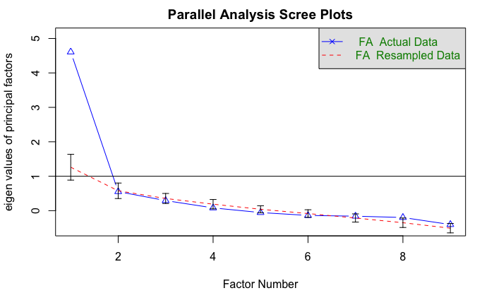

```r
fa.parallel(motivation_bogota_0[ , -c(1,3,12,13)], fm='ml', fa='fa', main="Parallel Analysis Scree Plots", n.iter=100, error.bars=T, sim=F)
```

```r
fa(r=motivation_bogota_0[ , -c(1,3,12,13)], nfactors=2, rotate='promax', fm='ml')
```

```
Factor Analysis using method =  ml
Call: fa(r = motivation_bogota_0[, -c(1, 3, 12, 13)], nfactors = 2,
    rotate = "promax", fm = "ml")
Standardized loadings (pattern matrix) based upon correlation matrix
```

|  | ML1 | ML2 | h2 | u2 | com |
| --- | --- | --- | --- | --- | --- |
| excellent_programmer | 0.17 | 0.61 | 0.5515312 | 0.4484688 | 1.150704 |
| introduce_ideas | 0.04 | 0.73 | 0.5862449 | 0.4137551 | 1.006782 |
| get_in_touch | 0.64 | 0.22 | 0.6653687 | 0.3346313 | 1.235429 |
| known_creativity | 0.24 | 0.42 | 0.3811327 | 0.6188673 | 1.609226 |
| improve_skills | 0.87 | -0.11 | 0.6324863 | 0.3675137 | 1.032590 |
| test_capability | 1.03 | -0.16 | 0.8565749 | 0.1434251 | 1.048104 |
| enjoy_problems | 0.69 | 0.12 | 0.6078719 | 0.3921281 | 1.065497 |
| keep_up | 0.31 | 0.36 | 0.3879348 | 0.6120652 | 1.953059 |
| dissatisfaction | -0.27 | 1.05 | 0.7621236 | 0.2378764 | 1.132146 |

```
                       ML1  ML2
SS loadings           2.99 2.44
Proportion Var        0.33 0.27
Cumulative Var        0.33 0.60
Proportion Explained  0.55 0.45
Cumulative Proportion 0.55 1.00

 With factor correlations of
     ML1  ML2
ML1 1.00 0.72
ML2 0.72 1.00

Mean item complexity =  1.2
Test of the hypothesis that 2 factors are sufficient.

The degrees of freedom for the null model are  36  and the objective function was  5.65 with Chi Square of  198.84
The degrees of freedom for the model are 19  and the objective function was  0.77

The root mean square of the residuals (RMSR) is  0.06
The df corrected root mean square of the residuals is  0.08

The harmonic number of observations is  40 with the empirical chi square  10.27  with prob <  0.95
The total number of observations was  40  with Likelihood Chi Square =  25.93  with prob <  0.13

Tucker Lewis Index of factoring reliability =  0.915
RMSEA index =  0.092  and the 90 % confidence intervals are  0 0.182
BIC =  -44.16
Fit based upon off diagonal values = 0.99
Measures of factor score adequacy
                                                   ML1  ML2
Correlation of (regression) scores with factors   0.96 0.94
Multiple R square of scores with factors          0.93 0.89
Minimum correlation of possible factor scores     0.86 0.78
```

## Interpretation:

> Cumulative variance now at 55%. “get_in_touch” moved to intrinsic category

> Items loaded on ML1 - “excellent_programmer”, “introduce_ideas”, “known_creativity”, and “dissatisfaction”.

> Items loaded on ML2 - “improve_skills”, “test_capability”, “enjoy_problems”, “get_in_touch”

```r
# subset of bogota 0
survey_bogota_1 <- subset(survey, hack_id == 1)
survey_bogota_1
```

|  | monetary_compensation | excellent_programmer | internship | introduce_ideas | get_in_touch | known_creativity | improve_skills | test_capability | enjoy_problems | keep_up | dissatisfaction | curious | pass_class | Q3_Q3_1 | Q3_Q3_2 | Q3_Q3_3 | Q3_Q3_4 | Q3_Q3_5 | Q4_Q4_1 | Q4_Q4_2 | Q4_Q4_3 | Q4_Q4_4 | Q4_Q4_5 | Q5_Q5_1 | Q5_Q5_2 | Q5_Q5_3 | Q5_Q5_4 | Q5_Q5_5 | Q7_Q7_1 | … |
| --- | --- | --- | --- | --- | --- | --- | --- | --- | --- | --- | --- | --- | --- | --- | --- | --- | --- | --- | --- | --- | --- | --- | --- | --- | --- | --- | --- | --- | --- | --- |
| 3 | 3 | 2 | 6 | 2 | 2 | 2 | 6 | 5 | 3 | 6 | 4 | 6 | 6 | 6 | 5 | 5 | 5 | 4 | 4 | 2 | 4 | 3 | 4 | 3 | 2 | 5 | 3 | 6 | 0 | … |
| 7 | 0 | 2 | 3 | 2 | 2 | 4 | 5 | 5 | 4 | 5 | 1 | 1 | 3 | 3 | 4 | 4 | 4 | 4 | 5 | 5 | 5 | 5 | 5 | 3 | 3 | 4 | 3 | 4 | 1 | … |
| 11 | 3 | 4 | 4 | 1 | 4 | 4 | 4 | 3 | 3 | 2 | 0 | 2 | 5 | 1 | 4 | 2 | 2 | 3 | 3 | 4 | 2 | 1 | 3 | 0 | 0 | 3 | 0 | 4 | 0 | … |
| 15 | 0 | 4 | 4 | 4 | 4 | 5 | 4 | 5 | 4 | 4 | 5 | 4 | 5 | 3 | 3 | 3 | 3 | 3 | 3 | 3 | 4 | 3 | 4 | 3 | 1 | 3 | 1 | 5 | 0 | … |
| 19 | 0 | 5 | 3 | 1 | 3 | 3 | 6 | 6 | 5 | 6 | 5 | 4 | 4 | 4 | 5 | 4 | 3 | 4 | 5 | 3 | 3 | 3 | 3 | 2 | 3 | 4 | 4 | 6 | 2 | … |
| 23 | 3 | 4 | 4 | 3 | 4 | 5 | 5 | 6 | 4 | 5 | 2 | 4 | 5 | 2 | 5 | 3 | 4 | 5 | 3 | 2 | 5 | 5 | 4 | 1 | 0 | 2 | 0 | 5 | 0 | … |
| 27 | 6 | 4 | 6 | 1 | 3 | 6 | 5 | 3 | 3 | 6 | 5 | 6 | 6 | 0 | 5 | 5 | 5 | 5 | 3 | 5 | 5 | 1 | 5 | 1 | 5 | 4 | 1 | 4 | 0 | … |
| 31 | 5 | 5 | 6 | 4 | 5 | 5 | 6 | 5 | 5 | 5 | 5 | 4 | 5 | 4 | 5 | 5 | 6 | 4 | 5 | 4 | 5 | 5 | 5 | 4 | 3 | 4 | 5 | 5 | 1 | … |
| 33 | 3 | 5 | 6 | 4 | 4 | 5 | 6 | 4 | 5 | 5 | 5 | 6 | 3 | 5 | 6 | 4 | 6 | 5 | 4 | 4 | 5 | 4 | 5 | 5 | 4 | 5 | 6 | 6 | 4 | … |
| 34 | 2 | 5 | 5 | 4 | 4 | 5 | 5 | 5 | 5 | 3 | 6 | 5 | 3 | 4 | 5 | 4 | 5 | 5 | 5 | 5 | 5 | 5 | 5 | 5 | 4 | 5 | 5 | 5 | 5 | … |

[output cut: 32 more lines]

```r
motivation_bogota_1 <- survey_bogota_1[c(1:13)]
motivation_bogota_1
```

|  | monetary_compensation | excellent_programmer | internship | introduce_ideas | get_in_touch | known_creativity | improve_skills | test_capability | enjoy_problems | keep_up | dissatisfaction | curious | pass_class |
| --- | --- | --- | --- | --- | --- | --- | --- | --- | --- | --- | --- | --- | --- |
| 3 | 3 | 2 | 6 | 2 | 2 | 2 | 6 | 5 | 3 | 6 | 4 | 6 | 6 |
| 7 | 0 | 2 | 3 | 2 | 2 | 4 | 5 | 5 | 4 | 5 | 1 | 1 | 3 |
| 11 | 3 | 4 | 4 | 1 | 4 | 4 | 4 | 3 | 3 | 2 | 0 | 2 | 5 |
| 15 | 0 | 4 | 4 | 4 | 4 | 5 | 4 | 5 | 4 | 4 | 5 | 4 | 5 |
| 19 | 0 | 5 | 3 | 1 | 3 | 3 | 6 | 6 | 5 | 6 | 5 | 4 | 4 |
| 23 | 3 | 4 | 4 | 3 | 4 | 5 | 5 | 6 | 4 | 5 | 2 | 4 | 5 |
| 27 | 6 | 4 | 6 | 1 | 3 | 6 | 5 | 3 | 3 | 6 | 5 | 6 | 6 |
| 31 | 5 | 5 | 6 | 4 | 5 | 5 | 6 | 5 | 5 | 5 | 5 | 4 | 5 |
| 33 | 3 | 5 | 6 | 4 | 4 | 5 | 6 | 4 | 5 | 5 | 5 | 6 | 3 |
| 34 | 2 | 5 | 5 | 4 | 4 | 5 | 5 | 5 | 5 | 3 | 6 | 5 | 3 |

[output cut: 32 more lines]

```r
KMO(motivation_bogota_1)
```

```
Kaiser-Meyer-Olkin factor adequacy
Call: KMO(r = motivation_bogota_1)
Overall MSA =  0.79
MSA for each item =
monetary_compensation  excellent_programmer            internship       introduce_ideas          get_in_touch      known_creativity
                 0.65                  0.78                  0.82                  0.71                  0.95                  0.86
       improve_skills       test_capability        enjoy_problems               keep_up       dissatisfaction               curious
                 0.66                  0.86                  0.80                  0.84                  0.63                  0.82
           pass_class
                 0.58
```

```r
lowerCor(motivation_bogota_1)
```

```
                      mntr_ excl_ intrn intr_ gt_n_ knwn_ impr_ tst_c enjy_ kep_p dssts curis pss_c
monetary_compensation  1.00
excellent_programmer   0.46  1.00
internship             0.31  0.50  1.00
introduce_ideas        0.22  0.52  0.41  1.00
get_in_touch           0.29  0.65  0.54  0.66  1.00
known_creativity       0.50  0.75  0.48  0.48  0.56  1.00
improve_skills         0.14  0.33  0.56  0.14  0.45  0.28  1.00
test_capability        0.12  0.50  0.43  0.49  0.68  0.46  0.59  1.00
enjoy_problems         0.32  0.58  0.58  0.66  0.76  0.57  0.59  0.78  1.00
keep_up                0.19  0.40  0.43  0.37  0.55  0.44  0.69  0.67  0.60  1.00
dissatisfaction        0.05  0.44  0.34  0.53  0.45  0.28  0.42  0.43  0.35  0.48  1.00
curious                0.38  0.45  0.55  0.55  0.66  0.50  0.51  0.58  0.74  0.68  0.47  1.00
pass_class             0.15 -0.20 -0.08 -0.36 -0.36 -0.07 -0.24 -0.30 -0.45 -0.23 -0.13 -0.36  1.00
```

```
Parallel analysis suggests that the number of factors =  1  and the number of components =  NA
```

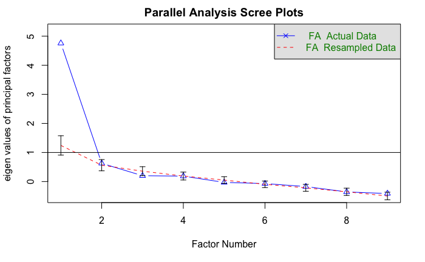

```r
fa.parallel(motivation_bogota_1[ , -c(1,3,12,13)], fm='ml', fa='fa', main="Parallel Analysis Scree Plots", n.iter=100, error.bars=T, sim=F)
```

```r
fa(r=motivation_bogota_1[ , -c(1,3,12,13)], nfactors=2, rotate='oblimin', fm='ml')
```

```
Factor Analysis using method =  ml
Call: fa(r = motivation_bogota_1[, -c(1, 3, 12, 13)], nfactors = 2,
    rotate = "oblimin", fm = "ml")
Standardized loadings (pattern matrix) based upon correlation matrix
```

|  | ML2 | ML1 | h2 | u2 | com |
| --- | --- | --- | --- | --- | --- |
| excellent_programmer | 0.72 | 0.01 | 0.5279442 | 0.472055820 | 1.000756 |
| introduce_ideas | 0.90 | -0.26 | 0.6777702 | 0.322229786 | 1.166471 |
| get_in_touch | 0.83 | 0.08 | 0.7516246 | 0.248375384 | 1.020482 |
| known_creativity | 0.69 | -0.02 | 0.4607343 | 0.539265696 | 1.001730 |
| improve_skills | 0.01 | 1.00 | 0.9950002 | 0.004999762 | 1.000054 |
| test_capability | 0.62 | 0.32 | 0.6609557 | 0.339044279 | 1.501700 |
| enjoy_problems | 0.75 | 0.25 | 0.7989319 | 0.201068076 | 1.221450 |
| keep_up | 0.38 | 0.52 | 0.5868252 | 0.413174794 | 1.824043 |
| dissatisfaction | 0.40 | 0.24 | 0.3068601 | 0.693139904 | 1.639349 |

```
                       ML2  ML1
SS loadings           3.98 1.79
Proportion Var        0.44 0.20
Cumulative Var        0.44 0.64
Proportion Explained  0.69 0.31
Cumulative Proportion 0.69 1.00

 With factor correlations of
     ML2  ML1
ML2 1.00 0.44
ML1 0.44 1.00

Mean item complexity =  1.3
Test of the hypothesis that 2 factors are sufficient.

The degrees of freedom for the null model are  36  and the objective function was  6.54 with Chi Square of  243.11
The degrees of freedom for the model are 19  and the objective function was  1.07

The root mean square of the residuals (RMSR) is  0.07
The df corrected root mean square of the residuals is  0.09

The harmonic number of observations is  42 with the empirical chi square  13.53  with prob <  0.81
The total number of observations was  42  with Likelihood Chi Square =  38.3  with prob <  0.0054

Tucker Lewis Index of factoring reliability =  0.816
RMSEA index =  0.154  and the 90 % confidence intervals are  0.083 0.229
BIC =  -32.71
Fit based upon off diagonal values = 0.98
Measures of factor score adequacy
                                                   ML2  ML1
Correlation of (regression) scores with factors   0.96 1.00
Multiple R square of scores with factors          0.92 1.00
Minimum correlation of possible factor scores     0.85 0.99
```

```r
# subset of bogota 2
survey_bogota_2 <- subset(survey, hack_id == 2)
survey_bogota_2
```

|  | monetary_compensation | excellent_programmer | internship | introduce_ideas | get_in_touch | known_creativity | improve_skills | test_capability | enjoy_problems | keep_up | dissatisfaction | curious | pass_class | Q3_Q3_1 | Q3_Q3_2 | Q3_Q3_3 | Q3_Q3_4 | Q3_Q3_5 | Q4_Q4_1 | Q4_Q4_2 | Q4_Q4_3 | Q4_Q4_4 | Q4_Q4_5 | Q5_Q5_1 | Q5_Q5_2 | Q5_Q5_3 | Q5_Q5_4 | Q5_Q5_5 | Q7_Q7_1 | … |
| --- | --- | --- | --- | --- | --- | --- | --- | --- | --- | --- | --- | --- | --- | --- | --- | --- | --- | --- | --- | --- | --- | --- | --- | --- | --- | --- | --- | --- | --- | --- |
| 4 | 4 | 4 | 3 | 0 | 0 | 0 | 6 | 6 | 5 | 6 | 0 | 0 | 6 | 3 | 5 | 5 | 6 | 5 | 0 | 0 | 0 | 0 | 0 | 0 | 0 | 4 | 0 | 5 | 0 | … |
| 8 | 4 | 5 | 4 | 3 | 4 | 5 | 5 | 4 | 4 | 5 | 3 | 4 | 4 | 5 | 5 | 4 | 4 | 5 | 5 | 4 | 5 | 4 | 5 | 5 | 4 | 5 | 4 | 5 | 5 | … |
| 12 | 5 | 3 | 5 | 1 | 1 | 4 | 6 | 6 | 6 | 6 | 4 | 6 | 0 | 4 | 5 | 4 | 6 | 5 | 5 | 0 | 6 | 4 | 6 | 2 | 0 | 5 | 4 | 6 | 1 | … |
| 16 | 5 | 5 | 4 | 4 | 3 | 6 | 5 | 5 | 5 | 5 | 3 | 4 | 6 | 6 | 5 | 6 | 5 | 5 | 4 | 5 | 5 | 4 | 4 | 1 | 1 | 4 | 1 | 5 | 0 | … |
| 20 | 4 | 4 | 5 | 1 | 4 | 4 | 6 | 5 | 2 | 5 | 3 | 5 | 3 | 5 | 5 | 6 | 6 | 5 | 4 | 5 | 3 | 4 | 5 | 6 | 1 | 5 | 3 | 6 | 3 | … |
| 24 | 4 | 4 | 4 | 4 | 4 | 4 | 4 | 4 | 4 | 4 | 4 | 4 | 4 | 4 | 4 | 4 | 4 | 4 | 5 | 5 | 5 | 5 | 5 | 4 | 4 | 4 | 4 | 4 | 4 | … |
| 28 | 4 | 6 | 4 | 5 | 4 | 4 | 5 | 5 | 4 | 5 | 0 | 5 | 6 | 5 | 6 | 5 | 5 | 5 | 5 | 5 | 4 | 5 | 5 | 5 | 5 | 5 | 5 | 5 | 4 | … |
| 32 | 3 | 4 | 5 | 1 | 4 | 3 | 6 | 5 | 3 | 4 | 2 | 4 | 6 | 2 | 5 | 4 | 5 | 6 | 1 | 4 | 2 | 1 | 5 | 3 | 1 | 5 | 1 | 5 | 1 | … |
| 41 | 0 | 4 | 3 | 3 | 4 | 4 | 6 | 5 | 5 | 5 | 5 | 4 | 4 | 5 | 5 | 6 | 5 | 5 | 2 | 2 | 2 | 2 | 5 | 4 | 5 | 6 | 1 | 5 | 1 | … |
| 44 | 1 | 5 | 5 | 3 | 4 | 5 | 5 | 5 | 5 | 3 | 1 | 4 | 5 | 4 | 5 | 5 | 5 | 5 | 4 | 3 | 3 | 3 | 4 | 2 | 1 | 4 | 2 | 5 | 1 | … |

[output cut: 30 more lines]

```r
motivation_bogota_2 <- survey_bogota_2[c(1:13)]
motivation_bogota_2
```

|  | monetary_compensation | excellent_programmer | internship | introduce_ideas | get_in_touch | known_creativity | improve_skills | test_capability | enjoy_problems | keep_up | dissatisfaction | curious | pass_class |
| --- | --- | --- | --- | --- | --- | --- | --- | --- | --- | --- | --- | --- | --- |
| 4 | 4 | 4 | 3 | 0 | 0 | 0 | 6 | 6 | 5 | 6 | 0 | 0 | 6 |
| 8 | 4 | 5 | 4 | 3 | 4 | 5 | 5 | 4 | 4 | 5 | 3 | 4 | 4 |
| 12 | 5 | 3 | 5 | 1 | 1 | 4 | 6 | 6 | 6 | 6 | 4 | 6 | 0 |
| 16 | 5 | 5 | 4 | 4 | 3 | 6 | 5 | 5 | 5 | 5 | 3 | 4 | 6 |
| 20 | 4 | 4 | 5 | 1 | 4 | 4 | 6 | 5 | 2 | 5 | 3 | 5 | 3 |
| 24 | 4 | 4 | 4 | 4 | 4 | 4 | 4 | 4 | 4 | 4 | 4 | 4 | 4 |
| 28 | 4 | 6 | 4 | 5 | 4 | 4 | 5 | 5 | 4 | 5 | 0 | 5 | 6 |
| 32 | 3 | 4 | 5 | 1 | 4 | 3 | 6 | 5 | 3 | 4 | 2 | 4 | 6 |
| 41 | 0 | 4 | 3 | 3 | 4 | 4 | 6 | 5 | 5 | 5 | 5 | 4 | 4 |
| 44 | 1 | 5 | 5 | 3 | 4 | 5 | 5 | 5 | 5 | 3 | 1 | 4 | 5 |

[output cut: 30 more lines]

```r
describe(motivation_bogota_2)
```

|  | vars | n | mean | sd | median | trimmed | mad | min | max | range | skew | kurtosis | se |
| --- | --- | --- | --- | --- | --- | --- | --- | --- | --- | --- | --- | --- | --- |
| monetary_compensation | 1 | 40 | 3.30 | 1.62 | 3.5 | 3.38 | 1.48 | 0 | 6 | 6 | -0.37 | -0.58 | 0.26 |
| excellent_programmer | 2 | 40 | 4.30 | 1.24 | 4.0 | 4.38 | 1.48 | 1 | 6 | 5 | -0.49 | -0.33 | 0.20 |
| internship | 3 | 40 | 4.20 | 1.30 | 4.0 | 4.28 | 1.48 | 1 | 6 | 5 | -0.43 | -0.53 | 0.21 |
| introduce_ideas | 4 | 40 | 3.05 | 1.54 | 3.0 | 3.12 | 1.48 | 0 | 6 | 6 | -0.37 | -0.65 | 0.24 |
| get_in_touch | 5 | 40 | 3.72 | 1.43 | 4.0 | 3.88 | 1.48 | 0 | 6 | 6 | -0.90 | 0.65 | 0.23 |
| known_creativity | 6 | 40 | 3.88 | 1.36 | 4.0 | 4.03 | 1.48 | 0 | 6 | 6 | -1.09 | 1.44 | 0.22 |
| improve_skills | 7 | 40 | 5.03 | 1.12 | 5.0 | 5.22 | 1.48 | 2 | 6 | 4 | -1.11 | 0.54 | 0.18 |
| test_capability | 8 | 40 | 4.65 | 1.25 | 5.0 | 4.81 | 1.48 | 1 | 6 | 5 | -1.02 | 0.47 | 0.20 |
| enjoy_problems | 9 | 40 | 4.08 | 1.42 | 4.0 | 4.22 | 1.48 | 0 | 6 | 6 | -0.96 | 0.47 | 0.22 |
| keep_up | 10 | 40 | 4.50 | 1.15 | 5.0 | 4.59 | 1.48 | 2 | 6 | 4 | -0.63 | -0.48 | 0.18 |

[output cut: 3 more lines]

```r
KMO(motivation_bogota_2)
```

```
Kaiser-Meyer-Olkin factor adequacy
Call: KMO(r = motivation_bogota_2)
Overall MSA =  0.7
MSA for each item =
monetary_compensation  excellent_programmer            internship       introduce_ideas          get_in_touch      known_creativity
                 0.74                  0.66                  0.71                  0.60                  0.61                  0.69
       improve_skills       test_capability        enjoy_problems               keep_up       dissatisfaction               curious
                 0.68                  0.83                  0.87                  0.68                  0.83                  0.76
           pass_class
                 0.34
```

```r
lowerCor(motivation_bogota_2)
```

```
                      mntr_ excl_ intrn intr_ gt_n_ knwn_ impr_ tst_c enjy_ kep_p dssts curis pss_c
monetary_compensation  1.00
excellent_programmer   0.49  1.00
internship             0.27  0.66  1.00
introduce_ideas        0.43  0.38  0.28  1.00
get_in_touch           0.27  0.45  0.35  0.65  1.00
known_creativity       0.24  0.49  0.46  0.44  0.40  1.00
improve_skills         0.43  0.64  0.51  0.12  0.39  0.32  1.00
test_capability        0.43  0.55  0.42  0.16  0.26  0.41  0.83  1.00
enjoy_problems         0.32  0.55  0.45  0.29  0.40  0.38  0.64  0.59  1.00
keep_up                0.53  0.48  0.51  0.26  0.10  0.46  0.70  0.73  0.51  1.00
dissatisfaction        0.33  0.26  0.21  0.48  0.46  0.43  0.24  0.17  0.36  0.23  1.00
curious                0.17  0.34  0.60  0.32  0.46  0.62  0.40  0.34  0.44  0.39  0.37  1.00
pass_class             0.03  0.27 -0.13  0.00  0.14  0.05  0.20  0.24 -0.03  0.04 -0.08 -0.18  1.00
```

```
Parallel analysis suggests that the number of factors =  2  and the number of components =  NA
```

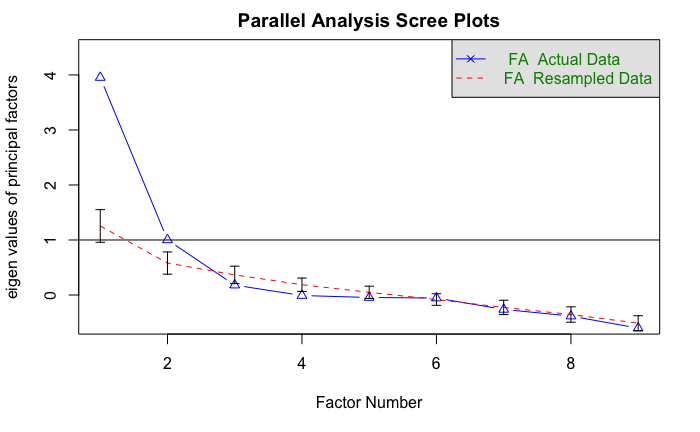

```r
fa.parallel(motivation_bogota_2[ , -c(1,3,12,13)], fm='ml', fa='fa', main="Parallel Analysis Scree Plots", n.iter=100, error.bars=T, sim=F)
```

```r
fa(r=motivation_bogota_2[ , -c(1,3,12,13)], nfactors=2, rotate='oblimin', fm='ml')
```

```
Factor Analysis using method =  ml
Call: fa(r = motivation_bogota_2[, -c(1, 3, 12, 13)], nfactors = 2,
    rotate = "oblimin", fm = "ml")
Standardized loadings (pattern matrix) based upon correlation matrix
```

|  | ML1 | ML2 | h2 | u2 | com |
| --- | --- | --- | --- | --- | --- |
| excellent_programmer | 0.57 | 0.31 | 0.5398588 | 0.4601412 | 1.534607 |
| introduce_ideas | -0.11 | 0.90 | 0.7580826 | 0.2419174 | 1.028428 |
| get_in_touch | 0.14 | 0.70 | 0.5737712 | 0.4262288 | 1.080214 |
| known_creativity | 0.27 | 0.47 | 0.3809270 | 0.6190730 | 1.605050 |
| improve_skills | 0.96 | -0.06 | 0.8849311 | 0.1150689 | 1.008259 |
| test_capability | 0.91 | -0.06 | 0.7850454 | 0.2149546 | 1.008865 |
| enjoy_problems | 0.62 | 0.21 | 0.5196494 | 0.4803506 | 1.238434 |
| keep_up | 0.75 | 0.03 | 0.5829086 | 0.4170914 | 1.003527 |
| dissatisfaction | 0.08 | 0.56 | 0.3455673 | 0.6544327 | 1.038905 |

```
                       ML1  ML2
SS loadings           3.26 2.11
Proportion Var        0.36 0.23
Cumulative Var        0.36 0.60
Proportion Explained  0.61 0.39
Cumulative Proportion 0.61 1.00

 With factor correlations of
     ML1  ML2
ML1 1.00 0.35
ML2 0.35 1.00

Mean item complexity =  1.2
Test of the hypothesis that 2 factors are sufficient.

The degrees of freedom for the null model are  36  and the objective function was  5.66 with Chi Square of  198.95
The degrees of freedom for the model are 19  and the objective function was  0.96

The root mean square of the residuals (RMSR) is  0.06
The df corrected root mean square of the residuals is  0.08

The harmonic number of observations is  40 with the empirical chi square  9.32  with prob <  0.97
The total number of observations was  40  with Likelihood Chi Square =  32.64  with prob <  0.026

Tucker Lewis Index of factoring reliability =  0.834
RMSEA index =  0.132  and the 90 % confidence intervals are  0.046 0.213
BIC =  -37.45
Fit based upon off diagonal values = 0.98
Measures of factor score adequacy
                                                   ML1  ML2
Correlation of (regression) scores with factors   0.97 0.92
Multiple R square of scores with factors          0.94 0.85
Minimum correlation of possible factor scores     0.88 0.71
```

```r
# subset of bogota 3
survey_bogota_3 <- subset(survey, hack_id == 3)
survey_bogota_3
```

|  | monetary_compensation | excellent_programmer | internship | introduce_ideas | get_in_touch | known_creativity | improve_skills | test_capability | enjoy_problems | keep_up | dissatisfaction | curious | pass_class | Q3_Q3_1 | Q3_Q3_2 | Q3_Q3_3 | Q3_Q3_4 | Q3_Q3_5 | Q4_Q4_1 | Q4_Q4_2 | Q4_Q4_3 | Q4_Q4_4 | Q4_Q4_5 | Q5_Q5_1 | Q5_Q5_2 | Q5_Q5_3 | Q5_Q5_4 | Q5_Q5_5 | Q7_Q7_1 | … |
| --- | --- | --- | --- | --- | --- | --- | --- | --- | --- | --- | --- | --- | --- | --- | --- | --- | --- | --- | --- | --- | --- | --- | --- | --- | --- | --- | --- | --- | --- | --- |
| 1 | 3 | 5 | 5 | 3 | 4 | 3 | 5 | 5 | 3 | 3 | 3 | 3 | 6 | 4 | 5 | 5 | 5 | 4 | 4 | 4 | 4 | 4 | 4 | 5 | 5 | 4 | 5 | 6 | 4 | … |
| 5 | 1 | 5 | 5 | 2 | 2 | 3 | 5 | 4 | 3 | 4 | 4 | 4 | 6 | 3 | 4 | 3 | 5 | 4 | 6 | 2 | 6 | 3 | 6 | 3 | 3 | 4 | 0 | 4 | 1 | … |
| 9 | 3 | 3 | 6 | 3 | 4 | 5 | 6 | 4 | 5 | 5 | 4 | 4 | 5 | 4 | 6 | 6 | 6 | 5 | 4 | 4 | 5 | 4 | 5 | 3 | 2 | 4 | 3 | 5 | 1 | … |
| 13 | 4 | 5 | 3 | 4 | 4 | 5 | 4 | 4 | 5 | 5 | 5 | 4 | 3 | 4 | 4 | 4 | 4 | 2 | 4 | 3 | 4 | 3 | 3 | 4 | 3 | 3 | 5 | 4 | 4 | … |
| 17 | 3 | 5 | 5 | 4 | 5 | 5 | 5 | 4 | 5 | 4 | 3 | 4 | 4 | 5 | 4 | 4 | 5 | 3 | 3 | 3 | 4 | 4 | 4 | 4 | 4 | 6 | 4 | 6 | 1 | … |
| 21 | 5 | 2 | 4 | 3 | 1 | 3 | 5 | 4 | 3 | 3 | 4 | 4 | 6 | 4 | 2 | 5 | 3 | 4 | 1 | 3 | 4 | 3 | 5 | 5 | 2 | 4 | 3 | 4 | 0 | … |
| 25 | 5 | 6 | 6 | 4 | 6 | 6 | 6 | 6 | 6 | 6 | 3 | 5 | 3 | 4 | 6 | 4 | 6 | 5 | 4 | 6 | 4 | 3 | 5 | 2 | 1 | 5 | 1 | 5 | 0 | … |
| 29 | 3 | 4 | 5 | 3 | 5 | 4 | 5 | 5 | 5 | 4 | 2 | 5 | 6 | 4 | 4 | 5 | 5 | 5 | 4 | 5 | 4 | 4 | 5 | 4 | 3 | 5 | 3 | 6 | 3 | … |
| 35 | 0 | 0 | 1 | 0 | 0 | 0 | 4 | 0 | 0 | 1 | 4 | 0 | 6 | 6 | 3 | 5 | 3 | 3 | 5 | 2 | 5 | 5 | 2 | 3 | 2 | 3 | 4 | 4 | 0 | … |
| 37 | 0 | 6 | 3 | 0 | 1 | 5 | 4 | 2 | 5 | 3 | 1 | 4 | 5 | 4 | 3 | 2 | 4 | 3 | 4 | 3 | 4 | 3 | 5 | 1 | 2 | 2 | 2 | 1 | 1 | … |

[output cut: 31 more lines]

```r
motivation_bogota_3 <- survey_bogota_3[c(1:13)]
motivation_bogota_3
```

|  | monetary_compensation | excellent_programmer | internship | introduce_ideas | get_in_touch | known_creativity | improve_skills | test_capability | enjoy_problems | keep_up | dissatisfaction | curious | pass_class |
| --- | --- | --- | --- | --- | --- | --- | --- | --- | --- | --- | --- | --- | --- |
| 1 | 3 | 5 | 5 | 3 | 4 | 3 | 5 | 5 | 3 | 3 | 3 | 3 | 6 |
| 5 | 1 | 5 | 5 | 2 | 2 | 3 | 5 | 4 | 3 | 4 | 4 | 4 | 6 |
| 9 | 3 | 3 | 6 | 3 | 4 | 5 | 6 | 4 | 5 | 5 | 4 | 4 | 5 |
| 13 | 4 | 5 | 3 | 4 | 4 | 5 | 4 | 4 | 5 | 5 | 5 | 4 | 3 |
| 17 | 3 | 5 | 5 | 4 | 5 | 5 | 5 | 4 | 5 | 4 | 3 | 4 | 4 |
| 21 | 5 | 2 | 4 | 3 | 1 | 3 | 5 | 4 | 3 | 3 | 4 | 4 | 6 |
| 25 | 5 | 6 | 6 | 4 | 6 | 6 | 6 | 6 | 6 | 6 | 3 | 5 | 3 |
| 29 | 3 | 4 | 5 | 3 | 5 | 4 | 5 | 5 | 5 | 4 | 2 | 5 | 6 |
| 35 | 0 | 0 | 1 | 0 | 0 | 0 | 4 | 0 | 0 | 1 | 4 | 0 | 6 |
| 37 | 0 | 6 | 3 | 0 | 1 | 5 | 4 | 2 | 5 | 3 | 1 | 4 | 5 |

[output cut: 31 more lines]

```r
describe(motivation_bogota_3)
```

|  | vars | n | mean | sd | median | trimmed | mad | min | max | range | skew | kurtosis | se |
| --- | --- | --- | --- | --- | --- | --- | --- | --- | --- | --- | --- | --- | --- |
| monetary_compensation | 1 | 41 | 2.83 | 1.60 | 3 | 2.91 | 1.48 | 0 | 5 | 5 | -0.66 | -0.80 | 0.25 |
| excellent_programmer | 2 | 41 | 4.10 | 1.55 | 4 | 4.24 | 1.48 | 0 | 6 | 6 | -0.75 | 0.19 | 0.24 |
| internship | 3 | 41 | 3.88 | 1.68 | 4 | 4.03 | 1.48 | 0 | 6 | 6 | -0.47 | -0.48 | 0.26 |
| introduce_ideas | 4 | 41 | 2.95 | 1.52 | 3 | 3.03 | 1.48 | 0 | 6 | 6 | -0.51 | -0.32 | 0.24 |
| get_in_touch | 5 | 41 | 3.71 | 1.58 | 4 | 3.82 | 1.48 | 0 | 6 | 6 | -0.67 | -0.28 | 0.25 |
| known_creativity | 6 | 41 | 3.68 | 1.49 | 4 | 3.79 | 1.48 | 0 | 6 | 6 | -0.61 | 0.11 | 0.23 |
| improve_skills | 7 | 41 | 4.90 | 1.39 | 5 | 5.18 | 1.48 | 0 | 6 | 6 | -2.00 | 3.91 | 0.22 |
| test_capability | 8 | 41 | 4.22 | 1.42 | 5 | 4.42 | 1.48 | 0 | 6 | 6 | -1.44 | 1.88 | 0.22 |
| enjoy_problems | 9 | 41 | 3.95 | 1.60 | 4 | 4.15 | 1.48 | 0 | 6 | 6 | -1.00 | 0.50 | 0.25 |
| keep_up | 10 | 41 | 4.10 | 1.45 | 4 | 4.24 | 1.48 | 0 | 6 | 6 | -1.09 | 1.15 | 0.23 |

[output cut: 3 more lines]

```r
KMO(motivation_bogota_3)
```

```
Kaiser-Meyer-Olkin factor adequacy
Call: KMO(r = motivation_bogota_3)
Overall MSA =  0.84
MSA for each item =
monetary_compensation  excellent_programmer            internship       introduce_ideas          get_in_touch      known_creativity
                 0.88                  0.94                  0.94                  0.84                  0.88                  0.79
       improve_skills       test_capability        enjoy_problems               keep_up       dissatisfaction               curious
                 0.82                  0.80                  0.80                  0.88                  0.70                  0.88
           pass_class
                 0.65
```

```
Parallel analysis suggests that the number of factors =  1  and the number of components =  NA
```

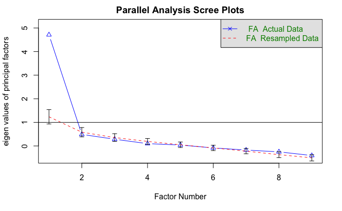

```r
fa.parallel(motivation_bogota_3[ , -c(1,3,12,13)], fm='ml', fa='fa', main="Parallel Analysis Scree Plots", n.iter=100, error.bars=T, sim=F)
```

```r
fa(r=motivation_bogota_3[ , -c(1,3,12,13)], nfactors=2, rotate='promax', fm='ml')
```

```
Factor Analysis using method =  ml
Call: fa(r = motivation_bogota_3[, -c(1, 3, 12, 13)], nfactors = 2,
    rotate = "promax", fm = "ml")
Standardized loadings (pattern matrix) based upon correlation matrix
```

|  | ML2 | ML1 | h2 | u2 | com |
| --- | --- | --- | --- | --- | --- |
| excellent_programmer | 0.30 | 0.56 | 0.6464064 | 0.35359365 | 1.514103 |
| introduce_ideas | 0.31 | 0.47 | 0.5231950 | 0.47680501 | 1.729936 |
| get_in_touch | 0.69 | 0.18 | 0.6857218 | 0.31427817 | 1.131478 |
| known_creativity | -0.33 | 1.20 | 0.9711036 | 0.02889637 | 1.153728 |
| improve_skills | 0.69 | -0.10 | 0.3837070 | 0.61629305 | 1.044714 |
| test_capability | 1.04 | -0.17 | 0.8660496 | 0.13395045 | 1.051200 |
| enjoy_problems | 0.30 | 0.49 | 0.5465523 | 0.45344765 | 1.677114 |
| keep_up | 0.60 | 0.29 | 0.6881809 | 0.31181905 | 1.449899 |
| dissatisfaction | 0.39 | 0.03 | 0.1699455 | 0.83005454 | 1.010722 |

```
                       ML2  ML1
SS loadings           3.02 2.46
Proportion Var        0.34 0.27
Cumulative Var        0.34 0.61
Proportion Explained  0.55 0.45
Cumulative Proportion 0.55 1.00

 With factor correlations of
     ML2  ML1
ML2 1.00 0.72
ML1 0.72 1.00

Mean item complexity =  1.3
Test of the hypothesis that 2 factors are sufficient.

The degrees of freedom for the null model are  36  and the objective function was  6.01 with Chi Square of  217.33
The degrees of freedom for the model are 19  and the objective function was  0.81

The root mean square of the residuals (RMSR) is  0.07
The df corrected root mean square of the residuals is  0.1

The harmonic number of observations is  41 with the empirical chi square  15.71  with prob <  0.68
The total number of observations was  41  with Likelihood Chi Square =  28.16  with prob <  0.08

Tucker Lewis Index of factoring reliability =  0.9
RMSEA index =  0.106  and the 90 % confidence intervals are  0 0.19
BIC =  -42.39
Fit based upon off diagonal values = 0.98
Measures of factor score adequacy
                                                   ML2  ML1
Correlation of (regression) scores with factors   0.96 0.99
Multiple R square of scores with factors          0.93 0.98
Minimum correlation of possible factor scores     0.86 0.95
```

## Confirmatory Factor Analaysis for Subsample

```r
# Then we define the model by specifying the relationship between items and factors:

path <-
'f1 =~ excellent_programmer + introduce_ideas + get_in_touch + known_creativity + dissatisfaction
f2 =~ improve_skills + test_capability + enjoy_problems + keep_up'
```

```r
library(lavaan)
model <- cfa(path, data= motivation_bogota_0)
summary(model, fit.measures=TRUE)
```

```
lavaan 0.6-9 ended normally after 34 iterations

  Estimator                                         ML
  Optimization method                           NLMINB
  Number of model parameters                        19

  Number of observations                            40

Model Test User Model:

  Test statistic                                48.737
  Degrees of freedom                                26
  P-value (Chi-square)                           0.004

Model Test Baseline Model:

  Test statistic                               226.169
  Degrees of freedom                                36
  P-value                                        0.000

User Model versus Baseline Model:

  Comparative Fit Index (CFI)                    0.880
  Tucker-Lewis Index (TLI)                       0.834

Loglikelihood and Information Criteria:

  Loglikelihood user model (H0)               -548.193
  Loglikelihood unrestricted model (H1)       -523.824

  Akaike (AIC)                                1134.385
  Bayesian (BIC)                              1166.474
  Sample-size adjusted Bayesian (BIC)         1107.018

Root Mean Square Error of Approximation:

  RMSEA                                          0.148
  90 Percent confidence interval - lower         0.081
  90 Percent confidence interval - upper         0.211
  P-value RMSEA <= 0.05                          0.014
```

[output cut: 28 more lines]

```
    f2                0.847    0.274    3.096    0.002

Variances:
                   Estimate  Std.Err  z-value  P(>|z|)
   .excllnt_prgrmm    0.890    0.244    3.650    0.000
   .introduce_ides    1.180    0.317    3.725    0.000
   .get_in_touch      1.056    0.300    3.514    0.000
   .known_creatvty    1.191    0.296    4.020    0.000
   .dissatisfactin    1.235    0.319    3.868    0.000
   .improve_skills    0.520    0.145    3.577    0.000
   .test_capabilty    0.535    0.194    2.766    0.006
   .enjoy_problems    0.679    0.195    3.492    0.000
   .keep_up           0.780    0.187    4.166    0.000
    f1                1.184    0.442    2.679    0.007
    f2                0.870    0.301    2.889    0.004
```

```r
library(lavaan)
model <- cfa(path, data= motivation_bogota_1)
summary(model, fit.measures=TRUE)
```

```
lavaan 0.6-9 ended normally after 31 iterations

  Estimator                                         ML
  Optimization method                           NLMINB
  Number of model parameters                        19

  Number of observations                            42

Model Test User Model:

  Test statistic                                63.984
  Degrees of freedom                                26
  P-value (Chi-square)                           0.000

Model Test Baseline Model:

  Test statistic                               274.728
  Degrees of freedom                                36
  P-value                                        0.000

User Model versus Baseline Model:

  Comparative Fit Index (CFI)                    0.841
  Tucker-Lewis Index (TLI)                       0.780

Loglikelihood and Information Criteria:

  Loglikelihood user model (H0)               -580.647
  Loglikelihood unrestricted model (H1)       -548.655

  Akaike (AIC)                                1199.293
  Bayesian (BIC)                              1232.309
  Sample-size adjusted Bayesian (BIC)         1172.810

Root Mean Square Error of Approximation:

  RMSEA                                          0.187
  90 Percent confidence interval - lower         0.129
  90 Percent confidence interval - upper         0.245
  P-value RMSEA <= 0.05                          0.000
```

[output cut: 28 more lines]

```
    f2                0.998    0.331    3.020    0.003

Variances:
                   Estimate  Std.Err  z-value  P(>|z|)
   .excllnt_prgrmm    1.151    0.300    3.832    0.000
   .introduce_ides    1.357    0.339    4.001    0.000
   .get_in_touch      0.596    0.206    2.886    0.004
   .known_creatvty    1.135    0.277    4.100    0.000
   .dissatisfactin    1.779    0.407    4.372    0.000
   .improve_skills    0.985    0.232    4.245    0.000
   .test_capabilty    0.405    0.125    3.239    0.001
   .enjoy_problems    0.364    0.135    2.697    0.007
   .keep_up           0.845    0.206    4.100    0.000
    f1                1.702    0.593    2.871    0.004
    f2                0.795    0.335    2.372    0.018
```

```r
library(lavaan)
model <- cfa(path, data= motivation_bogota_2)
summary(model, fit.measures=TRUE)
```

```
lavaan 0.6-9 ended normally after 32 iterations

  Estimator                                         ML
  Optimization method                           NLMINB
  Number of model parameters                        19

  Number of observations                            40

Model Test User Model:

  Test statistic                                59.968
  Degrees of freedom                                26
  P-value (Chi-square)                           0.000

Model Test Baseline Model:

  Test statistic                               226.299
  Degrees of freedom                                36
  P-value                                        0.000

User Model versus Baseline Model:

  Comparative Fit Index (CFI)                    0.821
  Tucker-Lewis Index (TLI)                       0.753

Loglikelihood and Information Criteria:

  Loglikelihood user model (H0)               -526.573
  Loglikelihood unrestricted model (H1)       -496.589

  Akaike (AIC)                                1091.147
  Bayesian (BIC)                              1123.236
  Sample-size adjusted Bayesian (BIC)         1063.780

Root Mean Square Error of Approximation:

  RMSEA                                          0.181
  90 Percent confidence interval - lower         0.121
  90 Percent confidence interval - upper         0.241
  P-value RMSEA <= 0.05                          0.001
```

[output cut: 28 more lines]

```
    f2                0.439    0.186    2.359    0.018

Variances:
                   Estimate  Std.Err  z-value  P(>|z|)
   .excllnt_prgrmm    0.876    0.233    3.766    0.000
   .introduce_ides    1.129    0.327    3.456    0.001
   .get_in_touch      0.868    0.272    3.192    0.001
   .known_creatvty    1.044    0.278    3.757    0.000
   .dissatisfactin    1.539    0.388    3.968    0.000
   .improve_skills    0.194    0.083    2.326    0.020
   .test_capabilty    0.289    0.108    2.677    0.007
   .enjoy_problems    1.039    0.251    4.141    0.000
   .keep_up           0.507    0.131    3.882    0.000
    f1                0.634    0.302    2.098    0.036
    f2                1.031    0.280    3.688    0.000
```

```r
library(lavaan)
model <- cfa(path, data= motivation_bogota_3)
summary(model, fit.measures=TRUE)
```

```
lavaan 0.6-9 ended normally after 33 iterations

  Estimator                                         ML
  Optimization method                           NLMINB
  Number of model parameters                        19

  Number of observations                            41

Model Test User Model:

  Test statistic                                54.958
  Degrees of freedom                                26
  P-value (Chi-square)                           0.001

Model Test Baseline Model:

  Test statistic                               246.371
  Degrees of freedom                                36
  P-value                                        0.000

User Model versus Baseline Model:

  Comparative Fit Index (CFI)                    0.862
  Tucker-Lewis Index (TLI)                       0.809

Loglikelihood and Information Criteria:

  Loglikelihood user model (H0)               -575.814
  Loglikelihood unrestricted model (H1)       -548.335

  Akaike (AIC)                                1189.629
  Bayesian (BIC)                              1222.187
  Sample-size adjusted Bayesian (BIC)         1162.709

Root Mean Square Error of Approximation:

  RMSEA                                          0.165
  90 Percent confidence interval - lower         0.103
  90 Percent confidence interval - upper         0.226
  P-value RMSEA <= 0.05                          0.003
```

[output cut: 28 more lines]

```
    f2                0.964    0.327    2.947    0.003

Variances:
                   Estimate  Std.Err  z-value  P(>|z|)
   .excllnt_prgrmm    0.771    0.218    3.537    0.000
   .introduce_ides    0.960    0.247    3.883    0.000
   .get_in_touch      0.891    0.242    3.675    0.000
   .known_creatvty    0.983    0.249    3.947    0.000
   .dissatisfactin    2.109    0.477    4.421    0.000
   .improve_skills    1.202    0.282    4.263    0.000
   .test_capabilty    0.644    0.182    3.540    0.000
   .enjoy_problems    1.219    0.302    4.044    0.000
   .keep_up           0.475    0.162    2.936    0.003
    f1                1.561    0.505    3.093    0.002
    f2                0.691    0.337    2.052    0.040
```

```r
allData <- cbind(motivation, id = survey$hack_id)
allData
```

| monetary_compensation | excellent_programmer | internship | introduce_ideas | get_in_touch | known_creativity | improve_skills | test_capability | enjoy_problems | keep_up | dissatisfaction | curious | pass_class | f1 | f2 | id |
| --- | --- | --- | --- | --- | --- | --- | --- | --- | --- | --- | --- | --- | --- | --- | --- |
| 3 | 5 | 5 | 3 | 4 | 3 | 5 | 5 | 3 | 3 | 3 | 3 | 6 | 16 | 18 | 3 |
| 2 | 5 | 2 | 2 | 3 | 3 | 5 | 4 | 3 | 4 | 3 | 4 | 5 | 16 | 16 | 0 |
| 3 | 2 | 6 | 2 | 2 | 2 | 6 | 5 | 3 | 6 | 4 | 6 | 6 | 20 | 12 | 1 |
| 4 | 4 | 3 | 0 | 0 | 0 | 6 | 6 | 5 | 6 | 0 | 0 | 6 | 23 | 4 | 2 |
| 1 | 5 | 5 | 2 | 2 | 3 | 5 | 4 | 3 | 4 | 4 | 4 | 6 | 16 | 16 | 3 |
| 3 | 4 | 4 | 2 | 4 | 2 | 5 | 4 | 5 | 5 | 3 | 4 | 5 | 19 | 15 | 0 |
| 0 | 2 | 3 | 2 | 2 | 4 | 5 | 5 | 4 | 5 | 1 | 1 | 3 | 19 | 11 | 1 |
| 4 | 5 | 4 | 3 | 4 | 5 | 5 | 4 | 4 | 5 | 3 | 4 | 4 | 18 | 20 | 2 |
| 3 | 3 | 6 | 3 | 4 | 5 | 6 | 4 | 5 | 5 | 4 | 4 | 5 | 20 | 19 | 3 |
| 3 | 6 | 6 | 4 | 5 | 5 | 6 | 6 | 5 | 5 | 5 | 5 | 6 | 22 | 25 | 0 |

[output cut: 153 more lines]

```r
# subset of dataframe for anova factor 1
anova_1 <- allData[c(14, 16)]
anova_1
```

| f1 | id |
| --- | --- |
| 16 | 3 |
| 16 | 0 |
| 20 | 1 |
| 23 | 2 |
| 16 | 3 |
| 19 | 0 |
| 19 | 1 |
| 18 | 2 |
| 20 | 3 |
| 22 | 0 |

[output cut: 153 more lines]

```r
# Performing anova on factor 1
ANOVA_RESULTS_1 <- aov(f1 ~ id, data=anova_1)
summary(ANOVA_RESULTS_1)
```

```
             Df Sum Sq Mean Sq F value Pr(>F)
id            1      6   6.366   0.311  0.578
Residuals   161   3300  20.498
```

```r
# subset of dataframe for anova factor 2
anova_2 <- allData[c(15, 16)]
anova_2
```

| f2 | id |
| --- | --- |
| 18 | 3 |
| 16 | 0 |
| 12 | 1 |
| 4 | 2 |
| 16 | 3 |
| 15 | 0 |
| 11 | 1 |
| 20 | 2 |
| 19 | 3 |
| 25 | 0 |

[output cut: 153 more lines]

```r
# Performing anova on factor 2
ANOVA_RESULTS_2 <- aov(f2 ~ id, data=anova_2)
summary(ANOVA_RESULTS_2)
```

```
             Df Sum Sq Mean Sq F value Pr(>F)
id            1      1    0.70   0.019  0.889
Residuals   161   5762   35.79
```

## Interpretation:

> Factor 1 and Factor 2 are both not significant across the groups.

```r
# Maximum Likelihood Factor Analysis
# entering raw data and extracting 3 factors,
# with varimax rotation
fit <- factanal(motivation[1:13], 2, rotation="varimax", scores="Bartlett")
print(fit, digits=2, cutoff=.3, sort=TRUE)
```

```
Call:
factanal(x = motivation[1:13], factors = 2, scores = "Bartlett",     rotation = "varimax")

Uniquenesses:
monetary_compensation  excellent_programmer            internship       introduce_ideas          get_in_touch      known_creativity
                 0.78                  0.48                  0.57                  0.26                  0.38                  0.54
       improve_skills       test_capability        enjoy_problems               keep_up       dissatisfaction               curious
                 0.31                  0.31                  0.40                  0.43                  0.65                  0.61
           pass_class
                 0.95

Loadings:
                      Factor1 Factor2
improve_skills         0.82
test_capability        0.76    0.34
enjoy_problems         0.61    0.48
keep_up                0.66    0.36
excellent_programmer   0.47    0.54
introduce_ideas                0.85
get_in_touch           0.48    0.62
known_creativity       0.37    0.57
dissatisfaction                0.55
monetary_compensation          0.37
internship             0.48    0.45
curious                0.42    0.46
pass_class

               Factor1 Factor2
SS loadings       3.22    3.11
Proportion Var    0.25    0.24
Cumulative Var    0.25    0.49

Test of the hypothesis that 2 factors are sufficient.
The chi square statistic is 100.25 on 53 degrees of freedom.
The p-value is 9.53e-05
```

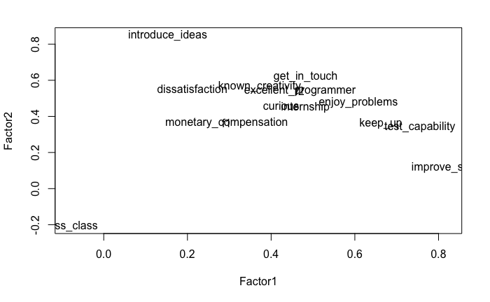

```r
# plot factor 1 by factor 2
load <- fit$loadings[,1:2]
plot(load,type="n") # set up plot
text(load,labels=names(motivation)) # add variable names
```

```r
fit_matrix <- fit$scores
fit_matrix
```

```
            Factor1       Factor2
  [1,] -0.093574045 -0.0895935396
  [2,] -0.053070762 -0.6885181408
  [3,]  1.165863077 -1.3010580271
  [4,]  2.214813696 -3.4105831386
  [5,]  0.022440354 -0.6650594479
  [6,]  0.432845896 -0.6382034916
  [7,]  0.457522265 -1.4192895425
  [8,]  0.014579156  0.2674518471
  [9,]  0.577717473 -0.0493113303
 [10,]  0.944925420  0.7038081185
 [11,] -0.713838081 -0.8327030195
 [12,]  1.950203904 -1.4613297287
 [13,] -0.764418057  1.2668454851
 [14,] -0.684237519 -0.2690930067
```

[output cut: 149 more lines]

## PCs as Data Frame from Matrix

```r
fit_df <- as.data.frame(fit_matrix)
fit_df
```

| Factor1 | Factor2 |
| --- | --- |
| -0.093574045 | -0.0895935396 |
| -0.053070762 | -0.6885181408 |
| 1.165863077 | -1.3010580271 |
| 2.214813696 | -3.4105831386 |
| 0.022440354 | -0.6650594479 |
| 0.432845896 | -0.6382034916 |
| 0.457522265 | -1.4192895425 |
| 0.014579156 | 0.2674518471 |
| 0.577717473 | -0.0493113303 |
| 0.944925420 | 0.7038081185 |

[output cut: 153 more lines]

## Combine hack_id with Factor Scores

```r
overall_fit <- cbind(fit_df, id = survey$hack_id)
overall_fit
```

| Factor1 | Factor2 | id |
| --- | --- | --- |
| -0.093574045 | -0.0895935396 | 3 |
| -0.053070762 | -0.6885181408 | 0 |
| 1.165863077 | -1.3010580271 | 1 |
| 2.214813696 | -3.4105831386 | 2 |
| 0.022440354 | -0.6650594479 | 3 |
| 0.432845896 | -0.6382034916 | 0 |
| 0.457522265 | -1.4192895425 | 1 |
| 0.014579156 | 0.2674518471 | 2 |
| 0.577717473 | -0.0493113303 | 3 |
| 0.944925420 | 0.7038081185 | 0 |

[output cut: 153 more lines]

## Combine Performance anmd Solution Groupings.

```r
overall_fit$performance <- ifelse(overall_fit$id==1, 1,
        ifelse(overall_fit$id==2, 0,
        ifelse(overall_fit$id==0, 0,
        ifelse(overall_fit$id==3, 1, NA))))

overall_fit
```

| Factor1 | Factor2 | id | performance |
| --- | --- | --- | --- |
| -0.093574045 | -0.0895935396 | 3 | 1 |
| -0.053070762 | -0.6885181408 | 0 | 0 |
| 1.165863077 | -1.3010580271 | 1 | 1 |
| 2.214813696 | -3.4105831386 | 2 | 0 |
| 0.022440354 | -0.6650594479 | 3 | 1 |
| 0.432845896 | -0.6382034916 | 0 | 0 |
| 0.457522265 | -1.4192895425 | 1 | 1 |
| 0.014579156 | 0.2674518471 | 2 | 0 |
| 0.577717473 | -0.0493113303 | 3 | 1 |
| 0.944925420 | 0.7038081185 | 0 | 0 |

[output cut: 153 more lines]

```r
overall_fit$solution <- ifelse(overall_fit$id==1, 0,
        ifelse(overall_fit$id==2, 1,
        ifelse(overall_fit$id==0, 0,
        ifelse(overall_fit$id==3, 1, NA))))

overall_fit
```

| Factor1 | Factor2 | id | performance | solution |
| --- | --- | --- | --- | --- |
| -0.093574045 | -0.0895935396 | 3 | 1 | 1 |
| -0.053070762 | -0.6885181408 | 0 | 0 | 0 |
| 1.165863077 | -1.3010580271 | 1 | 1 | 0 |
| 2.214813696 | -3.4105831386 | 2 | 0 | 1 |
| 0.022440354 | -0.6650594479 | 3 | 1 | 1 |
| 0.432845896 | -0.6382034916 | 0 | 0 | 0 |
| 0.457522265 | -1.4192895425 | 1 | 1 | 0 |
| 0.014579156 | 0.2674518471 | 2 | 0 | 1 |
| 0.577717473 | -0.0493113303 | 3 | 1 | 1 |
| 0.944925420 | 0.7038081185 | 0 | 0 | 0 |

[output cut: 153 more lines]

```r
overall_fit_abs <- abs(overall_fit)
overall_fit_abs
```

| Factor1 | Factor2 | id | performance | solution |
| --- | --- | --- | --- | --- |
| 0.093574045 | 0.0895935396 | 3 | 1 | 1 |
| 0.053070762 | 0.6885181408 | 0 | 0 | 0 |
| 1.165863077 | 1.3010580271 | 1 | 1 | 0 |
| 2.214813696 | 3.4105831386 | 2 | 0 | 1 |
| 0.022440354 | 0.6650594479 | 3 | 1 | 1 |
| 0.432845896 | 0.6382034916 | 0 | 0 | 0 |
| 0.457522265 | 1.4192895425 | 1 | 1 | 0 |
| 0.014579156 | 0.2674518471 | 2 | 0 | 1 |
| 0.577717473 | 0.0493113303 | 3 | 1 | 1 |
| 0.944925420 | 0.7038081185 | 0 | 0 | 0 |

[output cut: 153 more lines]

```r
allData <- cbind(survey, overall_fit_abs)
allData
```

```r
survey_bogota_0 <- subset(allData, hack_id == 0)
survey_bogota_0
```

```r
describe(survey_bogota_0$Factor1)
```

[output not shown]

```r
plot(survey_bogota_0$Factor1)
```

[output not shown]

## Descriptive Analysis for both factor 1 and factor 2

```r
describe(overall_fit_abs$Factor1)
```

[output not shown]

```r
res<-t.test(overall_fit_abs$performance, overall_fit_abs$Factor1 )
res
```

```
    Welch Two Sample t-test

data:  overall_fit_abs$performance and overall_fit_abs$Factor1
t = -4.5639, df = 283.97, p-value = 7.484e-06
alternative hypothesis: true difference in means is not equal to 0
95 percent confidence interval:
 -0.4591357 -0.1824342
sample estimates:
mean of x mean of y
0.5092025 0.8299874
```

```r
describe(overall_fit_abs$Factor2)
```

[output not shown]

```r
plot(overall_fit_abs$Factor2)
```

[output not shown]

## ANOVA across all 4 groups for Factor 1

```r
anova_1 <- aov(Factor1 ~ id, data=overall_fit_abs)
summary(anova_1)
```

[output not shown]

## Interpretation:

> No significance across all the 4 groups.

## ANOVA across all 4 groups for Factor 2

```r
anova_2 <- aov(Factor2 ~ id, data=overall_fit_abs)
summary(anova_2)
```

[output not shown]

## Interpretation:

> No significance across all the 4 groups.

## Unpaired t-test for Factor 1 [ 2 groups ]

```r
res<-t.test(overall_fit_abs$performance, overall_fit_abs$Factor1 )
res
```

[output not shown]

## Interpretation:

> Difference is significant

```r
res<-t.test(overall_fit_abs$solution, overall_fit_abs$Factor1 )
res
```

[output not shown]

## Interpretation:

> Difference is significant

## Unpaired t-test for Factor 2 [ 2 groups ]

```r
res<-t.test(overall_fit_abs$performance, overall_fit_abs$Factor2 )
res
```

[output not shown]

## Interpretation:

> Difference is significant

```r
res<-t.test(overall_fit_abs$solution, overall_fit_abs$Factor2 )
res
```

[output not shown]

## Interpretation:

> Difference is significant

```r
fa.res<-factanal(x=motivation[1:12], factors=3, rotation='promax')
print(fa.res, cut=0.5)
```

```
Call:
factanal(x = motivation[1:12], factors = 3, rotation = "promax")

Uniquenesses:
monetary_compensation  excellent_programmer            internship       introduce_ideas          get_in_touch      known_creativity
                0.782                 0.420                 0.567                 0.005                 0.398                 0.143
       improve_skills       test_capability        enjoy_problems               keep_up       dissatisfaction               curious
                0.344                 0.284                 0.406                 0.435                 0.652                 0.608

Loadings:
                      Factor1 Factor2 Factor3
monetary_compensation
excellent_programmer                   0.568
internship
introduce_ideas                1.218
get_in_touch
known_creativity                       1.186
improve_skills         1.122
test_capability        0.992
enjoy_problems         0.639
keep_up                0.723
dissatisfaction                0.554
curious

               Factor1 Factor2 Factor3
SS loadings      3.875   2.086   1.990
Proportion Var   0.323   0.174   0.166
Cumulative Var   0.323   0.497   0.663

Factor Correlations:
        Factor1 Factor2 Factor3
Factor1   1.000   0.724   0.742
Factor2   0.724   1.000   0.789
Factor3   0.742   0.789   1.000

Test of the hypothesis that 3 factors are sufficient.
The chi square statistic is 39.87 on 33 degrees of freedom.
The p-value is 0.191
```

## Interpretation:

The p-value for the chi-square test is 0.191 which is larger than .05. Therefore,we fail to reject the null hypothesis that the factor model have a good fit to the data.

```r
fa.res<-factanal(x=motivation[1:12], factors=3, rotation='promax', scores='Bartlett')
head(fa.res$scores)
```

```
         Factor1     Factor2    Factor3
[1,] -0.06549456 -0.03142867 -0.4340136
[2,] -0.38863948 -0.62385278 -0.5484743
[3,]  0.40859951 -0.47432647 -0.9940738
[4,]  0.32999501 -1.59250177 -2.1563255
[5,] -0.32214748 -0.60460169 -0.4604541
[6,]  0.11803775 -0.52857096 -0.9134604
```

```r
summary(lm(Factor2 ~ Factor1, data=as.data.frame(fa.res$scores)))
```

```
Call:
lm(formula = Factor2 ~ Factor1, data = as.data.frame(fa.res$scores))

Residuals:
     Min       1Q   Median       3Q      Max
-1.81715 -0.38994  0.05461  0.49701  1.35864

Coefficients:
              Estimate Std. Error t value Pr(>|t|)
(Intercept) -1.368e-16  5.559e-02    0.00        1
Factor1      6.808e-01  5.324e-02   12.79   <2e-16 ***
---
Signif. codes:  0 ‘***’ 0.001 ‘**’ 0.01 ‘*’ 0.05 ‘.’ 0.1 ‘ ’ 1

Residual standard error: 0.7097 on 161 degrees of freedom
Multiple R-squared:  0.5038,    Adjusted R-squared:  0.5008
F-statistic: 163.5 on 1 and 161 DF,  p-value: < 2.2e-16
```